# Transaction and Customer Behavior for Chip Products Analysis

Alif Safwan

2025-01-06

# Import the library

```r
library(dplyr) #manipulate data frame
library(ggplot2) #visualization
library(readxl) #read excel file
library(stringr) #manipulate string
library(tidyr) #reshape data frame format
library(tidytext) #text mining
library(car) #levene Test
library(PMCMRplus) # Post Hoc Test for Anova with unequal variance cases
library(arules) # Apriori algorithm
library(arulesViz) # Apriori algorithm visualisation
```

# Import the Transation and Customer Behavior Data

```r
#from excel file
Trans = read_excel("C:/Users/User/Documents/Project Forage/Quantium/QVI_transaction_data.xlsx")
```

```r
#from csv file
Cust = read.csv("C:/Users/User/Documents/Project Forage/Quantium/QVI_purchase_behaviour.csv")
```

# Exploratory Data Analysis for Transaction Data

```r
str(Trans)
```

```
## tibble [264,836 × 8] (S3: tbl_df/tbl/data.frame)
##  $ DATE          : num [1:264836] 43390 43599 43605 43329 43330 ...
##  $ STORE_NBR     : num [1:264836] 1 1 1 2 2 4 4 4 5 7 ...
##  $ LYLTY_CARD_NBR: num [1:264836] 1000 1307 1343 2373 2426 ...
##  $ TXN_ID        : num [1:264836] 1 348 383 974 1038 ...
##  $ PROD_NBR      : num [1:264836] 5 66 61 69 108 57 16 24 42 52 ...
##  $ PROD_NAME     : chr [1:264836] "Natural Chip        Compny SeaSalt175g" "CCs Nacho Cheese    175g" "Smiths Crinkle Cut  Chips Chicken 170g" "Smiths Chip Thinly  S/Cream&Onion 175g" ...
##  $ PROD_QTY      : num [1:264836] 2 3 2 5 3 1 1 1 1 2 ...
##  $ TOT_SALES     : num [1:264836] 6 6.3 2.9 15 13.8 5.1 5.7 3.6 3.9 7.2 ...
```

There are 8 variables and 264,836 observations in transaction data. 1) DATE : The date of transaction occurred 2) STORE_NBR : The unique ID assigned to each store 3) LYLTY_CARD_NBR : The unique ID for each customer 4) TXN_ID : The unique ID for each transaction 5) PROD_NBR : The unique ID for each chip product 6) PROD_NAME : The name of the chip product 7) PROD_QTY : The quantity purchased by the customer per transaction 8) TOT_SALES : The total price per transaction for chip product

Based on DATE variable, the date of the transaction is stored as an integer. Therefore, for better readability, we need to convert it to a date data type. Only two variables, PROD_QTY and TOT_SALES are true numerical variables. The rest may be stored as numeric data types, but they are actually just ID numbers.

```r
# csv and excel store dates as integers, where ) represents December 30, 1899
Trans <- Trans %>%
  mutate(DATE = as.Date(DATE, origin = "1899-12-30"))
```

```r
sum(duplicated(Trans))
```

```
## [1] 1
```

It seems there is one observation that entirely duplicated across all variables.

```r
Trans %>%
  filter(duplicated(.))
```

| DATE | STORE_NBR | LYLTY_CARD_NBR | TXN_ID | PROD_NBR | PROD_NAME | PROD_QTY | TOT_SALES |
| --- | --- | --- | --- | --- | --- | --- | --- |
| 2018-10-01 | 107 | 107024 | 108462 | 45 | Smiths Thinly Cut Roast Chicken 175g | 2 | 6 |

```r
Trans %>%
  filter(TXN_ID == 108462)
```

| DATE | STORE_NBR | LYLTY_CARD_NBR | TXN_ID | PROD_NBR | PROD_NAME | PROD_QTY | TOT_SALES |
| --- | --- | --- | --- | --- | --- | --- | --- |
| 2018-10-01 | 107 | 107024 | 108462 | 45 | Smiths Thinly Cut Roast Chicken 175g | 2 | 6.0 |
| 2018-10-01 | 107 | 107024 | 108462 | 18 | Cheetos Chs & Bacon Balls 190g | 2 | 6.6 |
| 2018-10-01 | 107 | 107024 | 108462 | 45 | Smiths Thinly Cut Roast Chicken 175g | 2 | 6.0 |

```r
Trans <- Trans %>%
  distinct()
```

Next, we want to know whether each observation represents a unique transaction.

```r
nrow(Trans) == n_distinct(Trans$TXN_ID)
```

```
## [1] FALSE
```

The result shows FALSE, indicating that the number of unique TXN_IDs is less than the number of observations, meaning that different products were purchased in the same transaction.

```r
Trans %>%
  group_by(TXN_ID) %>%
  summarise(unique_cust = n_distinct(LYLTY_CARD_NBR)) %>%
  filter(unique_cust > 1)
```

| TXN_ID | unique_cust |
| --- | --- |
| 155468 | 2 |
| 155469 | 2 |

There are two ’TXN_ID’s with more than one customer.

```r
Trans %>%
  filter(TXN_ID == 155468)
```

| DATE | STORE_NBR | LYLTY_CARD_NBR | TXN_ID | PROD_NBR | PROD_NAME | PROD_QTY | TOT_SALES |
| --- | --- | --- | --- | --- | --- | --- | --- |
| 2018-11-16 | 155 | 155072 | 155468 | 29 | French Fries Potato Chips 175g | 2 | 6.0 |
| 2018-08-13 | 155 | 155010 | 155468 | 10 | RRD SR Slow Rst Pork Belly 150g | 2 | 5.4 |

```r
Trans %>%
  filter(TXN_ID == 155469)
```

| DATE | STORE_NBR | LYLTY_CARD_NBR | TXN_ID | PROD_NBR | PROD_NAME | PROD_QTY | TOT_SALES |
| --- | --- | --- | --- | --- | --- | --- | --- |
| 2018-11-30 | 155 | 155072 | 155469 | 110 | WW Original Corn Chips 200g | 2 | 3.8 |
| 2019-06-05 | 155 | 155010 | 155469 | 77 | Doritos Corn Chips Nacho Cheese 170g | 2 | 8.8 |

Its look like both transactions occurred at STORE_NBR 155 and involved the same two customers.Perhaps by looking into the purchas history of these customers based on their ’LYLTY_CARD_NBR’s we can gain more insight.

```r
Trans %>%
  filter(LYLTY_CARD_NBR == 155072)
```

| DATE | STORE_NBR | LYLTY_CARD_NBR | TXN_ID | PROD_NBR | PROD_NAME | PROD_QTY | TOT_SALES |
| --- | --- | --- | --- | --- | --- | --- | --- |
| 2018-07-19 | 155 | 155072 | 155466 | 52 | Grain Waves Sour Cream&Chives 210G | 2 | 7.2 |
| 2018-11-15 | 155 | 155072 | 155467 | 105 | Woolworths Cheese Rings 190g | 2 | 3.6 |
| 2018-11-16 | 155 | 155072 | 155468 | 29 | French Fries Potato Chips 175g | 2 | 6.0 |
| 2018-11-30 | 155 | 155072 | 155469 | 110 | WW Original Corn Chips 200g | 2 | 3.8 |

```r
Trans %>%
  filter(LYLTY_CARD_NBR == 155010) %>%
  arrange(DATE)
```

| DATE | STORE_NBR | LYLTY_CARD_NBR | TXN_ID | PROD_NBR | PROD_NAME | PROD_QTY | TOT_SALES |
| --- | --- | --- | --- | --- | --- | --- | --- |
| 2018-08-13 | 155 | 155010 | 155468 | 10 | RRD SR Slow Rst Pork Belly 150g | 2 | 5.4 |
| 2019-01-15 | 155 | 155010 | 155061 | 47 | Doritos Corn Chips Original 170g | 2 | 8.8 |
| 2019-02-03 | 155 | 155010 | 155060 | 2 | Cobs Popd Sour Crm &Chives Chips 110g | 2 | 7.6 |
| 2019-02-20 | 155 | 155010 | 155062 | 103 | RRD Steak & Chimuchurri 150g | 2 | 5.4 |
| 2019-03-24 | 155 | 155010 | 155063 | 49 | Infuzions SourCream&Herbs Veg Strws 110g | 2 | 7.6 |
| 2019-04-02 | 155 | 155010 | 155064 | 88 | Kettle Honey Soy Chicken 175g | 2 | 10.8 |
| 2019-04-05 | 155 | 155010 | 155065 | 70 | Tyrrells Crisps Lightly Salted 165g | 2 | 8.4 |
| 2019-06-05 | 155 | 155010 | 155469 | 77 | Doritos Corn Chips Nacho Cheese 170g | 2 | 8.8 |

Since ’TXN_ID’s are uniquely assigned ID, we should leave them unchanged. However, it must be noted that if our analysis involves combining data based on ’TXN_ID, we should consult the client about these transactions ID in the given data to ensure data integrity is maintained.

There is only 1 category variable, which is ‘PROD_NAME’. Let’s examine the unique groups in this variable.

```r
unique(Trans$PROD_NAME)
```

```
##   [1] "Natural Chip        Compny SeaSalt175g"
##   [2] "CCs Nacho Cheese    175g"
##   [3] "Smiths Crinkle Cut  Chips Chicken 170g"
##   [4] "Smiths Chip Thinly  S/Cream&Onion 175g"
##   [5] "Kettle Tortilla ChpsHny&Jlpno Chili 150g"
##   [6] "Old El Paso Salsa   Dip Tomato Mild 300g"
##   [7] "Smiths Crinkle Chips Salt & Vinegar 330g"
##   [8] "Grain Waves         Sweet Chilli 210g"
##   [9] "Doritos Corn Chip Mexican Jalapeno 150g"
##  [10] "Grain Waves Sour    Cream&Chives 210G"
##  [11] "Kettle Sensations   Siracha Lime 150g"
##  [12] "Twisties Cheese     270g"
##  [13] "WW Crinkle Cut      Chicken 175g"
##  [14] "Thins Chips Light&  Tangy 175g"
##  [15] "CCs Original 175g"
```

[output cut: 99 more lines]

In total, there is 114 different products in this variable. ‘PROD_NAME’ includes both the pack size and brand name. Our goal is to clear and separate these components to ensure they are correctly split and labeled. This will help with further analysis, such as identifying whether any of the products are not a chip products.

```r
Trans <- Trans %>%
  mutate(
  # Extract packed_size (e.g., "175g", "300g")
  packed_size = str_extract(PROD_NAME, "[0-9]+"),

  # Extract product_brand (first word or phrase before product details)
  product_brand = str_extract(PROD_NAME, "^[^0-9]+?\\b"),

  # Remove brand and packed size to isolate product_name
  product_name = str_remove(PROD_NAME, paste0(packed_size, "[a-zA-Z]+\\b")) %>%
    str_remove(product_brand) %>%
    str_squish() # Remove extra spaces
  )
```

In the code above, ‘packed_size’ is extracted from ‘PROD_NAME’ by identifying a sequence of digits. Based on the unique product names, it’s safe to assume that each ‘PROD_NAME’ contains only one numeric sequence, which is followed by the character “g” or “G”.

As for ‘product_brand’, all brand names appear at the beginning of the ‘PROD_NAME’. Therefore, extracting the first word is a good initial step, but further cleaning is needed.

Lastly, ‘product_name’ is obtained by removing both the ‘packed_size’ and ‘product_brand’ from the original ‘PROD_NAME’. However, additional cleaning is necessary.

Further refinement is required for ‘product_brand’ because some brand names consist of more than one word, whereas our current method extracts only the first word. Also, some brands appear under different variations—such as “Red Rock Deli” and “RRD”—even though they refer to the same product

```r
Trans <- Trans %>%
  mutate(product_brand = case_when(
    product_brand == "Natural" ~ "Natural Chip Co.",
    product_brand == "Old" ~ "Old El Paso",
    product_brand == "Grain" ~ "Grain Waves",
    product_brand == "Burger" ~ "Burger Rings",
    product_brand == "Infzns" ~ "Infuzions",
    product_brand == "Red" ~ "Red Rock Deli",
    product_brand == "Dorito" ~ "Doritos",
    product_brand == "Smith" ~ "Smiths",
    product_brand == "GrnWves" ~ "Grain Waves",
    product_brand == "Tyrrells" ~ "Tyrrells Crisps",
    product_brand == "Cobs" ~ "Cobs",
    product_brand == "French" ~ "French Fries",
    product_brand == "RRD" ~ "Red Rock Deli",
    product_brand == "Snbts" ~ "Sunbites",
    product_brand == "NCC" ~ "Natural Chip Co.",
    product_brand == "WW" ~ "Woolworths",
    TRUE ~ product_brand
  ))
unique(Trans$product_brand)
```

```
##  [1] "Natural Chip Co." "CCs"              "Smiths"           "Kettle"
##  [5] "Old El Paso"      "Grain Waves"      "Doritos"          "Twisties"
##  [9] "Woolworths"       "Thins"            "Burger Rings"     "Cheezels"
## [13] "Infuzions"        "Red Rock Deli"    "Pringles"         "Tyrrells Crisps"
## [17] "Cobs"             "French Fries"     "Tostitos"         "Cheetos"
## [21] "Sunbites"
```

After cleaning, there are 21 product brands. Next, we want to look at the list of unique products under each brand.

```r
Trans %>%
  dplyr::select(PROD_NBR,product_brand,product_name) %>%
  filter(product_brand == "Natural Chip Co.") %>%
  unique()
```

| PROD_NBR | product_brand | product_name |
| --- | --- | --- |
| 5 | Natural Chip Co. | Chip Compny SeaSalt |
| 98 | Natural Chip Co. | Sour Cream & Garden Chives |
| 106 | Natural Chip Co. | ChipCo Hony Soy Chckn |
| 12 | Natural Chip Co. | Chip Co Tmato Hrb&Spce |
| 80 | Natural Chip Co. | ChipCo Sea Salt & Vinegr |

```r
Trans %>%
  dplyr::select(PROD_NBR,product_brand,product_name) %>%
  filter(product_brand == "CCs") %>%
  unique()
```

| PROD_NBR | product_brand | product_name |
| --- | --- | --- |
| 66 | CCs | Nacho Cheese |
| 54 | CCs | Original |
| 91 | CCs | Tasty Cheese |

```r
Trans %>%
  dplyr::select(PROD_NBR,product_brand,product_name) %>%
  filter(product_brand == "Smiths") %>%
  unique()
```

| PROD_NBR | product_brand | product_name |
| --- | --- | --- |
| 61 | Smiths | Crinkle Cut Chips Chicken |
| 69 | Smiths | Chip Thinly S/Cream&Onion |
| 16 | Smiths | Crinkle Chips Salt & Vinegar |
| 7 | Smiths | Crinkle Original |
| 111 | Smiths | Chip Thinly Cut Original |
| 37 | Smiths | Thinly Swt Chli&S/Cream |
| 107 | Smiths | Crinkle Cut French OnionDip |
| 45 | Smiths | Thinly Cut Roast Chicken |
| 39 | Smiths | Crinkle Cut Tomato Salsa |
| 82 | Smiths | Crinkle Cut Mac N Cheese |

[output cut: 8 more lines]

```r
Trans %>%
  dplyr::select(PROD_NBR,product_brand,product_name) %>%
  filter(product_brand == "Kettle") %>%
  unique()
```

| PROD_NBR | product_brand | product_name |
| --- | --- | --- |
| 108 | Kettle | Tortilla ChpsHny&Jlpno Chili |
| 114 | Kettle | Sensations Siracha Lime |
| 32 | Kettle | Sea Salt And Vinegar |
| 46 | Kettle | Original |
| 36 | Kettle | Chilli |
| 102 | Kettle | Mozzarella Basil & Pesto |
| 3 | Kettle | Sensations Camembert & Fig |
| 88 | Kettle | Honey Soy Chicken |
| 89 | Kettle | Sweet Chilli And Sour Cream |
| 63 | Kettle | Swt Pot Sea Salt |

[output cut: 3 more lines]

```r
Trans %>%
  dplyr::select(PROD_NBR,product_brand,product_name) %>%
  filter(product_brand == "Old El Paso") %>%
  unique()
```

| PROD_NBR | product_brand | product_name |
| --- | --- | --- |
| 57 | Old El Paso | El Paso Salsa Dip Tomato Mild |
| 65 | Old El Paso | El Paso Salsa Dip Chnky Tom Ht |
| 59 | Old El Paso | El Paso Salsa Dip Tomato Med |

```r
Trans %>%
  dplyr::select(PROD_NBR,product_brand,product_name) %>%
  filter(product_brand == "Grain Waves") %>%
  unique()
```

| PROD_NBR | product_brand | product_name |
| --- | --- | --- |
| 24 | Grain Waves | Waves Sweet Chilli |
| 52 | Grain Waves | Waves Sour Cream&Chives |
| 84 | Grain Waves | Plus Btroot & Chilli Jam |

```r
Trans %>%
  dplyr::select(PROD_NBR,product_brand,product_name) %>%
  filter(product_brand == "Doritos") %>%
  unique()
```

| PROD_NBR | product_brand | product_name |
| --- | --- | --- |
| 42 | Doritos | Corn Chip Mexican Jalapeno |
| 93 | Doritos | Corn Chip Southern Chicken |
| 51 | Doritos | Mexicana |
| 4 | Doritos | Corn Chp Supreme |
| 101 | Doritos | Salsa Medium |
| 47 | Doritos | Corn Chips Original |
| 30 | Doritos | Corn Chips Cheese Supreme |
| 77 | Doritos | Corn Chips Nacho Cheese |
| 20 | Doritos | Cheese Supreme |
| 41 | Doritos | Salsa Mild |

```r
Trans %>%
  dplyr::select(PROD_NBR,product_brand,product_name) %>%
  filter(product_brand == "Twisties") %>%
  unique()
```

| PROD_NBR | product_brand | product_name |
| --- | --- | --- |
| 15 | Twisties | Cheese |
| 113 | Twisties | Chicken |
| 71 | Twisties | Cheese Burger |

```r
Trans %>%
  dplyr::select(PROD_NBR,product_brand,product_name) %>%
  filter(product_brand == "Burger Rings") %>%
  unique()
```

| PROD_NBR | product_brand | product_name |
| --- | --- | --- |
| 94 | Burger Rings | Rings |

```r
Trans %>%
  dplyr::select(PROD_NBR,product_brand,product_name) %>%
  filter(product_brand == "Thins") %>%
  unique()
```

| PROD_NBR | product_brand | product_name |
| --- | --- | --- |
| 44 | Thins | Chips Light& Tangy |
| 22 | Thins | Chips Originl saltd |
| 40 | Thins | Chips Seasonedchicken |
| 28 | Thins | Potato Chips Hot & Spicy |
| 78 | Thins | Chips Salt & Vinegar |

```r
Trans %>%
  dplyr::select(PROD_NBR,product_brand,product_name) %>%
  filter(product_brand == "Cheezels") %>%
  unique()
```

| PROD_NBR | product_brand | product_name |
| --- | --- | --- |
| 56 | Cheezels | Cheese Box |
| 23 | Cheezels | Cheese |

```r
Trans %>%
  dplyr::select(PROD_NBR,product_brand,product_name) %>%
  filter(product_brand == "Infuzions") %>%
  unique()
```

| PROD_NBR | product_brand | product_name |
| --- | --- | --- |
| 31 | Infuzions | Crn Crnchers Tangy Gcamole |
| 104 | Infuzions | Thai SweetChili PotatoMix |
| 87 | Infuzions | BBQ Rib Prawn Crackers |
| 49 | Infuzions | SourCream&Herbs Veg Strws |
| 38 | Infuzions | Mango Chutny Papadums |

```r
Trans %>%
  dplyr::select(PROD_NBR,product_brand,product_name) %>%
  filter(product_brand == "Red Rock Deli") %>%
  unique()
```

| PROD_NBR | product_brand | product_name |
| --- | --- | --- |
| 13 | Red Rock Deli | Rock Deli Thai Chilli&Lime |
| 64 | Red Rock Deli | Rock Deli SR Salsa & Mzzrlla |
| 48 | Red Rock Deli | Rock Deli Sp Salt & Truffle |
| 67 | Red Rock Deli | Chilli& Coconut |
| 53 | Red Rock Deli | Sweet Chilli & Sour Cream |
| 103 | Red Rock Deli | Steak & Chimuchurri |
| 85 | Red Rock Deli | Honey Soy Chicken |
| 97 | Red Rock Deli | Salt & Vinegar |
| 6 | Red Rock Deli | Lime & Pepper |
| 58 | Red Rock Deli | Rock Deli Chikn&Garlic Aioli |

[output cut: 2 more lines]

```r
Trans %>%
  dplyr::select(PROD_NBR,product_brand,product_name) %>%
  filter(product_brand == "Pringles") %>%
  unique()
```

| PROD_NBR | product_brand | product_name |
| --- | --- | --- |
| 99 | Pringles | Sthrn FriedChicken |
| 26 | Pringles | Sweet&Spcy BBQ |
| 25 | Pringles | SourCream Onion |
| 81 | Pringles | Original Crisps |
| 68 | Pringles | Chicken Salt Crips |
| 109 | Pringles | Barbeque |
| 62 | Pringles | Mystery Flavour |
| 34 | Pringles | Slt Vingar |

```r
Trans %>%
  dplyr::select(PROD_NBR,product_brand,product_name) %>%
  filter(product_brand == "Tyrrells Crisps") %>%
  unique()
```

| PROD_NBR | product_brand | product_name |
| --- | --- | --- |
| 70 | Tyrrells Crisps | Crisps Lightly Salted |
| 112 | Tyrrells Crisps | Crisps Ched & Chives |

```r
Trans %>%
  dplyr::select(PROD_NBR,product_brand,product_name) %>%
  filter(product_brand == "Cobs") %>%
  unique()
```

| PROD_NBR | product_brand | product_name |
| --- | --- | --- |
| 33 | Cobs | Popd Swt/Chlli &Sr/Cream Chips |
| 75 | Cobs | Popd Sea Salt Chips |
| 2 | Cobs | Popd Sour Crm &Chives Chips |

```r
Trans %>%
  dplyr::select(PROD_NBR,product_brand,product_name) %>%
  filter(product_brand == "Woolworths") %>%
  unique()
```

| PROD_NBR | product_brand | product_name |
| --- | --- | --- |
| 92 | Woolworths | Crinkle Cut Chicken |
| 35 | Woolworths | Mild Salsa |
| 110 | Woolworths | Original Corn Chips |
| 83 | Woolworths | D/Style Chip Sea Salt |
| 96 | Woolworths | Original Stacked Chips |
| 72 | Woolworths | Crinkle Cut Original |
| 76 | Woolworths | Medium Salsa |
| 105 | Woolworths | Cheese Rings |
| 27 | Woolworths | Supreme Cheese Corn Chips |
| 21 | Woolworths | Sour Cream &OnionStacked Chips |

```r
Trans %>%
  dplyr::select(PROD_NBR,product_brand,product_name) %>%
  filter(product_brand == "French Fries") %>%
  unique()
```

| PROD_NBR | product_brand | product_name |
| --- | --- | --- |
| 29 | French Fries | Fries Potato Chips |

```r
Trans %>%
  dplyr::select(PROD_NBR,product_brand,product_name) %>%
  filter(product_brand == "Tostitos") %>%
  unique()
```

| PROD_NBR | product_brand | product_name |
| --- | --- | --- |
| 50 | Tostitos | Lightly Salted |
| 74 | Tostitos | Splash Of Lime |
| 90 | Tostitos | Smoked Chipotle |

```r
Trans %>%
  dplyr::select(PROD_NBR,product_brand,product_name) %>%
  filter(product_brand == "Cheetos") %>%
  unique()
```

| PROD_NBR | product_brand | product_name |
| --- | --- | --- |
| 86 | Cheetos | Puffs |
| 18 | Cheetos | Chs & Bacon Balls |

```r
Trans %>%
  dplyr::select(PROD_NBR,product_brand,product_name) %>%
  filter(product_brand == "Sunbites") %>%
  unique()
```

| PROD_NBR | product_brand | product_name |
| --- | --- | --- |
| 55 | Sunbites | Whlgrn Crisps Cheddr&Mstrd |
| 95 | Sunbites | Whlegrn Crisps Frch/Onin |

We rename certain products to proper name.

```r
Trans <- Trans %>%
  mutate(product_name = case_when(
    product_name == "Chip Compny SeaSalt" ~ "Sea Salt",
    product_name == "ChipCo Hony Soy Chckn" ~ "Honey Soy Chicken",
    product_name == "Chip Co Tmato Hrb&Spce" ~ "Tomato Herbs & Spices",
    product_name == "ChipCO Sea Salt & Vinegr" ~ "Sea Salt & Vinegar",
    product_name == "Chip Thinly S/Cream&Onion" ~ "Thinly Cut Sour Cream & Onion",
    product_name == "Chip Thinly Cut Original" ~ "Thinly Cut Original",
    product_name == "Thinly Swt Chli&S/Cream" ~ "Thinly Cut Sweet Chilli & Sour Cream",
    product_name == "Crinkle Cut French OnionDip" ~ "Crinkle Cut French Onion Dip",
    product_name == "Crinkle Cut Chips Chs&Onion" ~ "Crinkle Cut Chips Cheese & Onion",
    product_name == "Crnkle Chip Orgnl Big Bag" ~ "Crinkle Chip Original Big Bag",
    product_name == "Chip Thinly CutSalt/Vinegr" ~ "Thinly Cut Salt & Vinegar",
    product_name == "Crinkle Cut Snag&Sauce" ~ "Crinkle Cut Snag & Sauce",
    product_name == "Tortilla ChpsHny&Jlpno Chili" ~ "Tortilla Chips Honey & Jalapeno Chilli",
    product_name == "Swt Pot Sea Salt" ~ "Sweet Potato Sea Salt",
    product_name == "Sensations BBQ&Maple" ~ "Sensations BBQ & Maple",
    product_name == "Tortilla ChpsBtroot&Ricotta" ~ "Tortilla Chips Beetroot & Ricotta",
    product_name == "Tortilla ChpsFeta&Garlic" ~ "Tortilla Chips Feta & Garlic",
    product_name == "El Paso Salsa Dip Tomato Mild" ~ "Salsa Dip Tomato Mild",
    product_name == "El Paso Salsa Dip Chnky Tom Ht" ~ "Salsa Dip Chunky Tomato Hot",
    product_name == "El Paso Salsa Dip Tomato Med" ~ "Salsa Dip Tomato Medium",
    product_name == "Waves Sweet Chilli" ~ "Sweet Chilli",
    product_name == "Waves Sour Cream&Chives" ~ "Sour Cream & Chives",
    product_name == "Plus Btroot & Chilli Jam" ~ "Plus Beetroot & Chilli Jam",
    product_name == "Corn Chp Supreme" ~ "Corn Chip Supreme",
    product_name == "Sour Cream &OnionStacked Chips" ~ "Sour Cream & Onion Stacked Chips",
    product_name == "Chips Light& Tangy" ~ "Chips Light & Tangy",
    product_name == "Chips Originl saltd" ~ "Chips Original salted",
    product_name == "Chips Seasonedchicken" ~ "Chips Seasoned Chicken",
    product_name == "Crn Crnchers Tangy Gcamole" ~ "Corn Crunchers Tangy Gucamole",
    product_name == "Thai SweetChili PotatoMix" ~ "Thai Sweet Chili Potato Mix",
    product_name == "SourCream&Herbs Veg Strws" ~ "Sour Cream & Herbs Veggie Straws",
    product_name == "Mango Chutny Papadums" ~ "Mango Chutney Papadams",
    product_name == "Rock Deli Thai Chilli&Lime" ~ "Thai Chilli & Lime",
    product_name == "Rock Deli SR Salsa & Mzzrlla" ~ "SR Salsa & Mozzarella",
    product_name == "Rock Deli Sp Salt & Truffle" ~ "Sp Salt & Truffle",
    product_name == "Chilli& Coconut" ~ "Chilli & Coconut",
    product_name == "Rock Deli Chikn&Garlic Aioli" ~ "Chicken & Garlic Aioli",
    product_name == "SR Slow Rst Pork Belly" ~ "SR Slow Roast Pork Belly",
    product_name == "Sthrn FriedChicken" ~ "Southern Fried Chicken",
    product_name == "Sweet&Spcy BBQ" ~ "Sweet & Spicy BBQ",
    product_name == "SourCream Onion" ~ "Sour Cream Onion",
    product_name == "Slt Vingar" ~ "Salt Vinegar",
    product_name == "Popd Swt/Chlli &Sr/Cream Chips" ~ "Pop'd Sweet Chilli & Sour Cream Chips",
    product_name == "Popd Sea Salt Chips" ~ "Pop'd Sea Salt Chips",
    product_name == "Popd Sour Crm &Chives Chips" ~ "Pop'd Sour Cream & Chives Chips",
    product_name == "Fries Potato Chips" ~ "French Fries Potato Chips",
    product_name == "Rings" ~ "Burger Rings",
    product_name == "Chs & Bacon Balls" ~ "Cheese & Bacon Balls",
    product_name == "Whlgrn Crisps Cheddr&Mstrd" ~ "Wholegrain Crisps Cheddar & Mustard",
    product_name == "Whlegrn Crisps Frch/Onin" ~ "Wholegrain Crisps French Onion",
    TRUE ~ product_name
  ))
```

After reviewing all the products, we noticed that some of them are not chip products but are actually salsa dip.

```r
Trans %>%
  # Separate product_name into individual words
  mutate(product_name = str_replace_all(product_name, "\\s+", " ")) %>%
  unnest_tokens(word, product_name) %>%
  # Group by word and count occurrences
  count(word, sort = TRUE)
```

| word | n |
| --- | --- |
| chips | 59350 |
| salt | 33979 |
| cheese | 30850 |
| chicken | 27667 |
| crinkle | 27193 |
| cream | 26381 |
| sour | 26381 |
| original | 26234 |
| corn | 25207 |
| cut | 25127 |

[output cut: 114 more lines]

Since, “salsa” and “dip” are likely not chip products, we need to review them first. If they are indeed not chips, we should remove them from our dataset.

```r
Trans %>%
  dplyr::select(product_brand,product_name) %>%
  filter(str_detect(product_name, regex("salsa|dip",ignore_case = TRUE))) %>% unique()
```

| product_brand | product_name |
| --- | --- |
| Old El Paso | Salsa Dip Tomato Mild |
| Red Rock Deli | SR Salsa & Mozzarella |
| Smiths | Crinkle Cut French Onion Dip |
| Smiths | Crinkle Cut Tomato Salsa |
| Doritos | Salsa Medium |
| Old El Paso | Salsa Dip Chunky Tomato Hot |
| Woolworths | Mild Salsa |
| Old El Paso | Salsa Dip Tomato Medium |
| Woolworths | Medium Salsa |
| Doritos | Salsa Mild |

Some products still qualify as chip products even though their names contain “salsa” or “dip”. However, the rest are not chip products. Therefore, we will remove the non-chip products from our dataset.

```r
Trans <- Trans %>%
  filter(!(product_name %in% c("Salsa Dip Tomato Mild","Salsa Medium","Salsa Dip Chunky Tomato Hot","   Mild Salsa","Salsa Dip Tomato Medium","Medium Salsa","Salsa Mild")))
```

```r
unique(Trans$product_brand)
```

```
##  [1] "Natural Chip Co." "CCs"              "Smiths"           "Kettle"
##  [5] "Grain Waves"      "Doritos"          "Twisties"         "Woolworths"
##  [9] "Thins"            "Burger Rings"     "Cheezels"         "Infuzions"
## [13] "Red Rock Deli"    "Pringles"         "Tyrrells Crisps"  "Cobs"
## [17] "French Fries"     "Tostitos"         "Cheetos"          "Sunbites"
```

now that we’ve remove the non-chip products, we can see here only 20 product brands remain.

```r
str(Trans$packed_size)
```

```
##  chr [1:251160] "175" "175" "170" "175" "150" "330" "210" "150" "210" "330" ...
```

```r
unique(Trans$packed_size)
```

```
##  [1] "175" "170" "150" "330" "210" "270" "220" "125" "110" "134" "380" "180"
## [13] "165" "135" "250" "300" "200" "160" "190" "90"  "70"
```

The ‘packed_size’ is stored as a character type because we extracted it as a string. There are 21 different pack sizes across all products.

```r
colSums(is.na(Trans))
```

```
##           DATE      STORE_NBR LYLTY_CARD_NBR         TXN_ID       PROD_NBR
##              0              0              0              0              0
##      PROD_NAME       PROD_QTY      TOT_SALES    packed_size  product_brand
##              0              0              0              0              0
##   product_name
##              0
```

There are no missing values in any of the columns. Next, we check a simple summary for each column.

```r
summary(Trans)
```

```
##       DATE              STORE_NBR   LYLTY_CARD_NBR        TXN_ID
##  Min.   :2018-07-01   Min.   :  1   Min.   :   1000   Min.   :      1
##  1st Qu.:2018-09-30   1st Qu.: 70   1st Qu.:  70017   1st Qu.:  67576
##  Median :2018-12-30   Median :130   Median : 130352   Median : 135111
##  Mean   :2018-12-30   Mean   :135   Mean   : 135507   Mean   : 135112
##  3rd Qu.:2019-03-31   3rd Qu.:203   3rd Qu.: 203076   3rd Qu.: 202619
##  Max.   :2019-06-30   Max.   :272   Max.   :2373711   Max.   :2415841
##     PROD_NBR       PROD_NAME            PROD_QTY         TOT_SALES
##  Min.   :  1.00   Length:251160      Min.   :  1.000   Min.   :  1.500
##  1st Qu.: 27.00   Class :character   1st Qu.:  2.000   1st Qu.:  5.600
##  Median : 52.00   Mode  :character   Median :  2.000   Median :  7.400
##  Mean   : 56.17                      Mean   :  1.908   Mean   :  7.268
##  3rd Qu.: 86.00                      3rd Qu.:  2.000   3rd Qu.:  8.800
##  Max.   :114.00                      Max.   :200.000   Max.   :650.000
##  packed_size        product_brand      product_name
##  Length:251160      Length:251160      Length:251160
##  Class :character   Class :character   Class :character
##  Mode  :character   Mode  :character   Mode  :character
##
##
##
```

As we see, the maximum values for ‘PROD_QTY’ and ‘TOT_SALES’ are quite extreme. So, let’s take a look at the box plots for both of them.

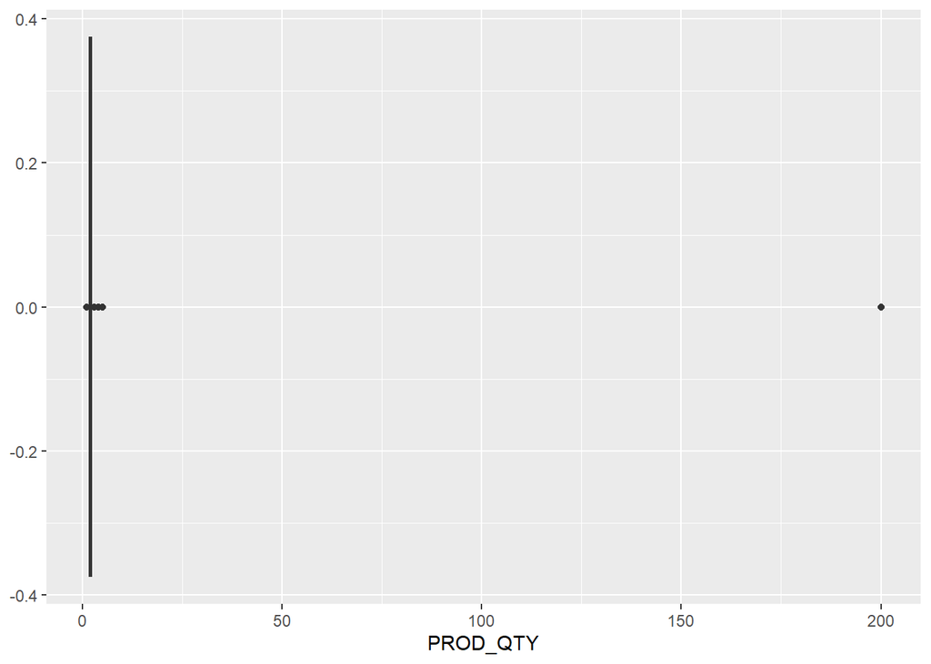

```r
Trans %>%
  ggplot(aes(x = PROD_QTY)) +
  geom_boxplot()
```

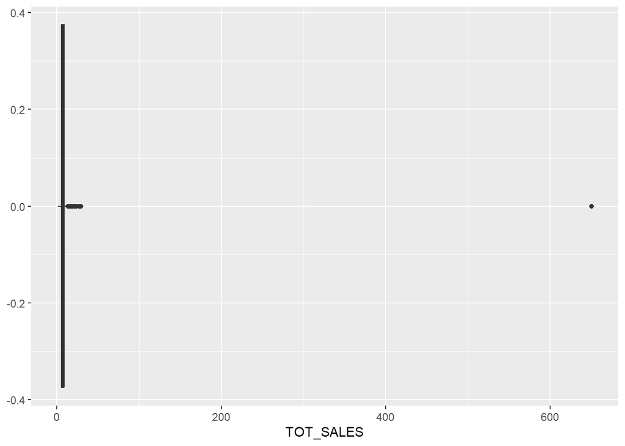

```r
Trans %>%
  ggplot(aes(x = TOT_SALES)) +
  geom_boxplot()
```

From the box plots, we can see that the extreme values are far away from the rest, they clearly stand out as outliers. So, let’s take a closer look at these outliers.

```r
Trans %>%
  filter(PROD_QTY == 200 | TOT_SALES == 650)
```

| DATE | STORE_NBR | LYLTY_CARD_NBR | TXN_ID | PROD_NBR | PROD_NAME | PROD_QTY | TOT_SALES | packed_size | product_brand | product_name |
| --- | --- | --- | --- | --- | --- | --- | --- | --- | --- | --- |
| 2018-08-19 | 226 | 226000 | 226201 | 4 | Dorito Corn Chp Supreme 380g | 200 | 650 | 380 | Doritos | Corn Chip Supreme |
| 2019-05-20 | 226 | 226000 | 226210 | 4 | Dorito Corn Chp Supreme 380g | 200 | 650 | 380 | Doritos | Corn Chip Supreme |

The result shows only two rows with extreme outliers, and both transactions were made by same loyalty card number.

```r
Trans %>%
  filter(LYLTY_CARD_NBR == 226000)
```

| DATE | STORE_NBR | LYLTY_CARD_NBR | TXN_ID | PROD_NBR | PROD_NAME | PROD_QTY | TOT_SALES | packed_size | product_brand | product_name |
| --- | --- | --- | --- | --- | --- | --- | --- | --- | --- | --- |
| 2018-08-19 | 226 | 226000 | 226201 | 4 | Dorito Corn Chp Supreme 380g | 200 | 650 | 380 | Doritos | Corn Chip Supreme |
| 2019-05-20 | 226 | 226000 | 226210 | 4 | Dorito Corn Chp Supreme 380g | 200 | 650 | 380 | Doritos | Corn Chip Supreme |

Based on output, this loyalty number made only those two outlier transactions. It’s possible that this person purchased for commercial purposes. So, we will exclude this customer from our dataset.

```r
Trans <- Trans %>%
  filter(LYLTY_CARD_NBR != 226000)
```

```r
summary(Trans)
```

```
##       DATE              STORE_NBR   LYLTY_CARD_NBR        TXN_ID
##  Min.   :2018-07-01   Min.   :  1   Min.   :   1000   Min.   :      1
##  1st Qu.:2018-09-30   1st Qu.: 70   1st Qu.:  70017   1st Qu.:  67575
##  Median :2018-12-30   Median :130   Median : 130352   Median : 135110
##  Mean   :2018-12-30   Mean   :135   Mean   : 135506   Mean   : 135111
##  3rd Qu.:2019-03-31   3rd Qu.:203   3rd Qu.: 203076   3rd Qu.: 202619
##  Max.   :2019-06-30   Max.   :272   Max.   :2373711   Max.   :2415841
##     PROD_NBR       PROD_NAME            PROD_QTY       TOT_SALES
##  Min.   :  1.00   Length:251158      Min.   :1.000   Min.   : 1.500
##  1st Qu.: 27.00   Class :character   1st Qu.:2.000   1st Qu.: 5.600
##  Median : 52.00   Mode  :character   Median :2.000   Median : 7.400
##  Mean   : 56.17                      Mean   :1.906   Mean   : 7.262
##  3rd Qu.: 86.00                      3rd Qu.:2.000   3rd Qu.: 8.800
##  Max.   :114.00                      Max.   :5.000   Max.   :29.500
##  packed_size        product_brand      product_name
##  Length:251158      Length:251158      Length:251158
##  Class :character   Class :character   Class :character
##  Mode  :character   Mode  :character   Mode  :character
##
##
##
```

By looking at the updated summary, it seems there are no longer any outliers in ‘PROD_QTY’ and “TOT_SALES.

Next, we want to check whether transactions occurred every day between 2018-07-01 and 2019-06-30. Specifically, how many days had no chip transactions?

```r
Trans %>%
  group_by(DATE) %>%
  summarise(total_trans_each_day = n()) %>%
  right_join(
    data.frame(DATE = seq.Date(from = min(Trans$DATE),to = max(Trans$DATE), by = "day"))) %>%
  filter(is.na(total_trans_each_day))
```

| DATE | total_trans_each_day |
| --- | --- |
| 2018-12-25 | NA |

We can see that only 25-12-2018 had no transactions, likely because it was Christmas and the stores were closed. There’s a clear gap between 24-12-2018 and 26-12-2018, and transaction volume appears to increase just before Christmas, probably due to holiday preparations.

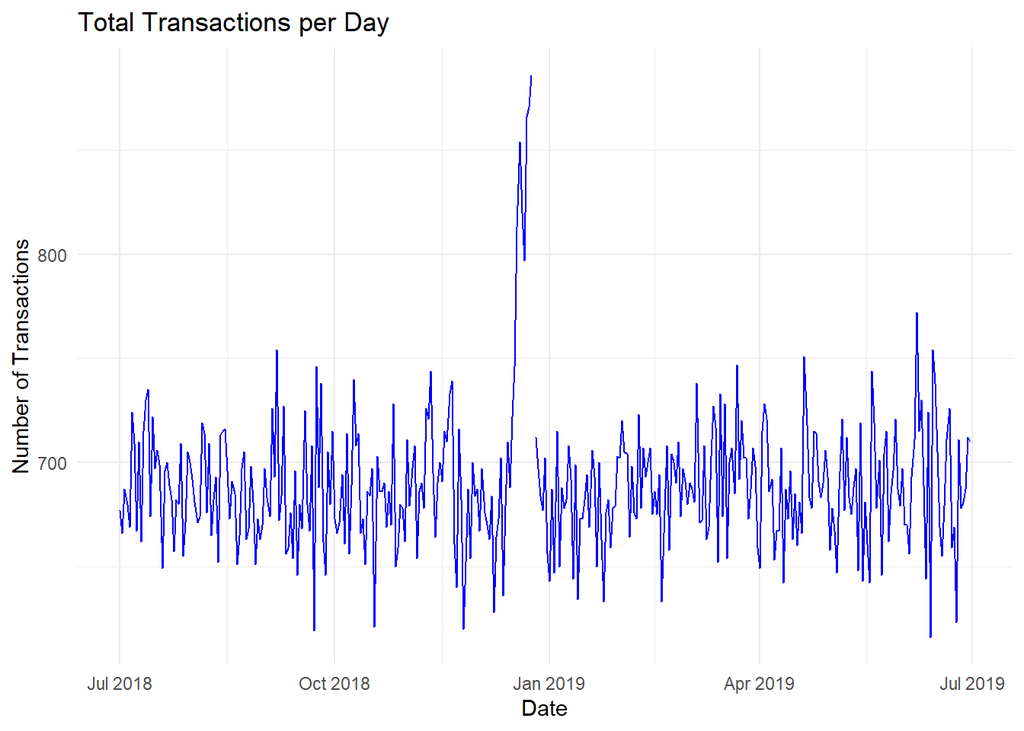

```r
Trans %>%
  group_by(DATE) %>%
  summarise(total_trans_each_day = n()) %>%
  right_join(
    data.frame(DATE = seq.Date(from = min(Trans$DATE),to = max(Trans$DATE), by = "day"))) %>%
  ggplot(aes(x = DATE, y = total_trans_each_day)) +
  geom_line(color = "blue") +
  labs(title = "Total Transactions per Day", x = "Date", y = "Number of Transactions") +
  theme_minimal()
```

The line plot gives a clear view of daily transaction patterns. You can easily spot the gap on 25-12-2018, and observe some spikes around major dates, like just before Christmas, indicating increased activity likely tied to holidays or events.

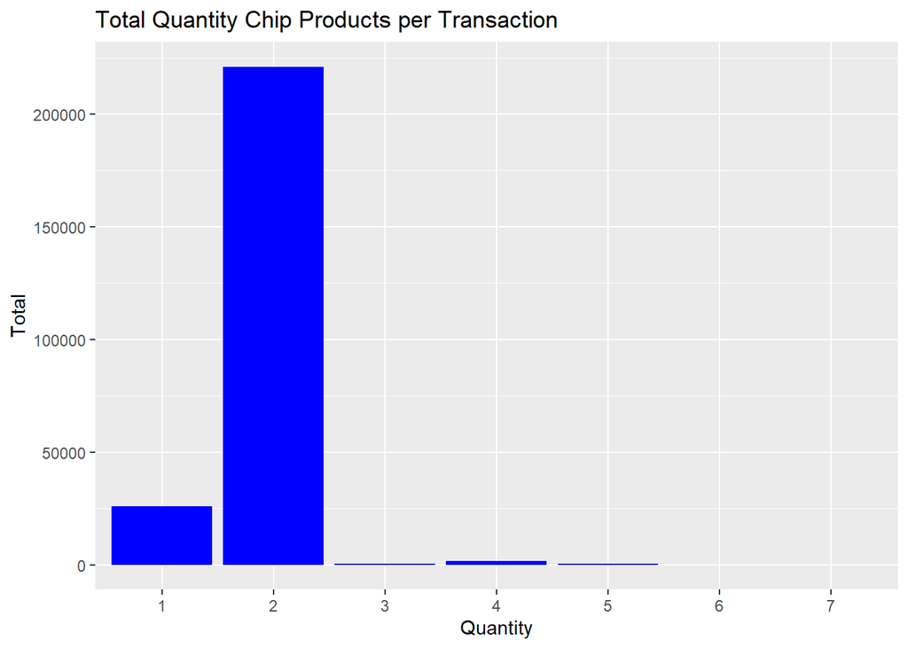

```r
Trans %>%
  group_by(TXN_ID) %>%
  summarise(Quantity = sum(PROD_QTY)) %>%
  ungroup() %>%
  ggplot(aes(x = as.factor(Quantity))) +
  geom_bar( fill = "blue") +
  labs( title =  "Total Quantity Chip Products per Transaction",
        x = "Quantity",
        y = "Total")
```

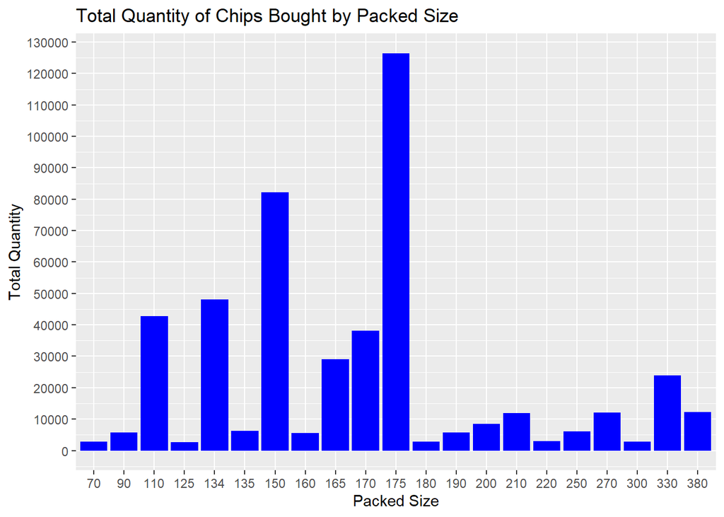

```r
Trans %>%
  group_by(packed_size) %>%
  summarise(total_count = sum(PROD_QTY, na.rm = TRUE)) %>%
  ggplot(aes(x = reorder(as.integer(packed_size), as.integer(packed_size)), y= total_count)) +
  geom_bar(stat = "identity", fill = "blue") +
  labs(title = "Total Quantity of Chips Bought by Packed Size",
       x = "Packed Size",
       y = "Total Quantity") +
  scale_y_continuous(breaks = seq(0,1000000, by = 10000))
```

The chart shows that most customers purchased chips in the 175g pack size, followed by the 150g pack size. This suggests that mid-sized packs are the most popular choice among buyers.

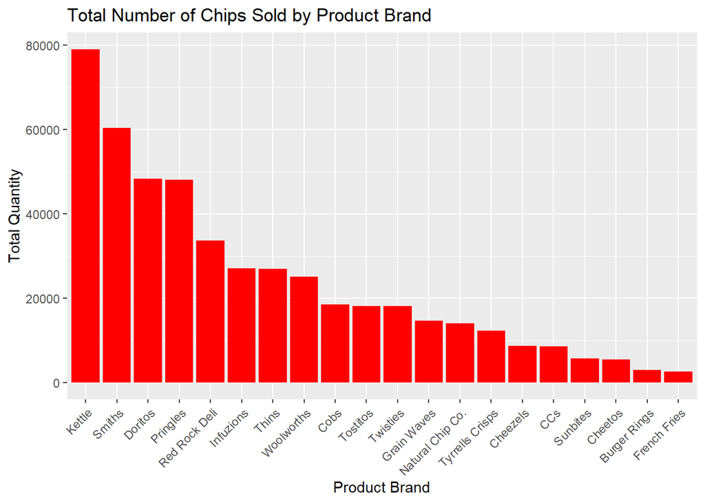

```r
Trans %>%
  group_by(product_brand) %>%
  summarise(total_count = sum(PROD_QTY)) %>%
  ggplot(aes(x = reorder(product_brand, - total_count), y = total_count)) +
  geom_bar(stat = "identity", fill = "red") +
  scale_x_discrete(guide = guide_axis(angle = 45)) +
  labs(title = "Total Number of Chips Sold by Product Brand", y = "Total Quantity", x = "Product Brand")
```

The most popular chip brand is Kettle, with nearly 80,000 units sold, followed by Smiths with close to 60,000 units, and Doritos with almost 50,000 units.

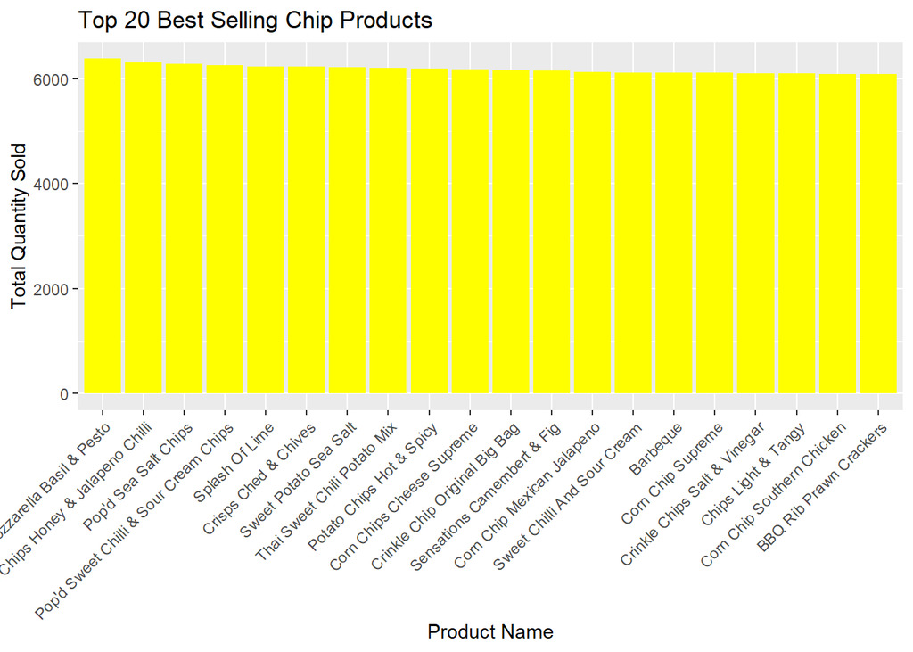

```r
Trans %>%
  group_by(product_name, product_brand) %>%
  summarise(total_count = sum(PROD_QTY)) %>%
  ungroup() %>%
  mutate(ranking = rank(desc(total_count))) %>%
  filter(ranking <= 20) %>%
  group_by(product_name, product_brand) %>%
  ggplot(aes(x = reorder(product_name, ranking), y = total_count)) +
  geom_bar(stat = "identity", fill = "yellow") +
  scale_x_discrete(guide = guide_axis(angle = 45)) +
  labs(title = "Top 20 Best Selling Chip Products", y = "Total Quantity Sold", x = "Product Name")
```

All of the top 20 products have nearly identical sales figures, with each selling around 6,000 units.

We also want to determine whether the price of each product is fixed or varies

```r
Trans %>%
  group_by(product_name) %>%
  summarise(avg_price = mean(TOT_SALES/PROD_QTY), sd_price = sd(TOT_SALES/PROD_QTY),
            max_price = max(TOT_SALES/PROD_QTY), min_price = min(TOT_SALES/PROD_QTY)) %>%
  filter(sd_price > 1e-03)
```

| product_name | avg_price | sd_price | max_price | min_price |
| --- | --- | --- | --- | --- |
| BBQ Rib Prawn Crackers | 3.799401 | 0.03372486 | 3.8 | 1.90 |
| Cheese | 5.152985 | 0.55003580 | 5.7 | 4.60 |
| Chilli | 5.399111 | 0.04898576 | 5.4 | 2.70 |
| Chips Salt & Vinegar | 3.298830 | 0.04626144 | 3.3 | 1.32 |
| Corn Chip Supreme | 6.368285 | 0.64097977 | 6.5 | 3.25 |
| Corn Chips Cheese Supreme | 4.399316 | 0.03878798 | 4.4 | 2.20 |
| Crinkle Cut Chips Chicken | 2.899023 | 0.03764012 | 2.9 | 1.45 |
| Crisps Ched & Chives | 4.199572 | 0.02448990 | 4.2 | 2.80 |
| Honey Soy Chicken | 4.234308 | 1.19960746 | 5.4 | 3.00 |
| Original | 4.330259 | 1.54465643 | 5.4 | 2.10 |

[output cut: 9 more lines]

In conclusion, from this EDA of the transaction data, we’ve uncovered several insights:

1. There was no transaction on December 25th, 2018, likely because stores were closed for the Christmas holiday. However, total sales in the days leading up to it were among the highest, suggesting that chips are a popular item for holiday preparations.
2. Most customers typically purchase 175g chip packs, followed by 150g. Larger pack sizes aren’t necessarily the most purchased, and it’s common for customers to buy two bags per transaction.
3. Overall, Kettle is the most popular chip brand, followed by Smiths, Doritos, and Pringles.
4. The top 20 chip products each recorded sales around 6,000 units.
5. There are 19 chip products with inconsistent pricing.

# Exploratory Data Analysis for Customer Behavior Data

```r
str(Cust)
```

```
## 'data.frame':    72637 obs. of  3 variables:
##  $ LYLTY_CARD_NBR  : int  1000 1002 1003 1004 1005 1007 1009 1010 1011 1012 ...
##  $ LIFESTAGE       : chr  "YOUNG SINGLES/COUPLES" "YOUNG SINGLES/COUPLES" "YOUNG FAMILIES" "OLDER SINGLES/COUPLES" ...
##  $ PREMIUM_CUSTOMER: chr  "Premium" "Mainstream" "Budget" "Mainstream" ...
```

There are 3 variables: the loyalty card number (LYLTY_CARD_NBR) for each customer, their lifestage (LIFESTAGE), and their premium customer status (PREMIUM_CUSTOMER).

```r
colSums(is.na(Cust))
```

```
##   LYLTY_CARD_NBR        LIFESTAGE PREMIUM_CUSTOMER
##                0                0                0
```

There are no missing values in this dataset. Since it represents customer behavior, each ‘LYLTY_CARD_NBR’ should ideally be unique.

```r
n_distinct(Cust$LYLTY_CARD_NBR) == nrow(Cust)
```

```
## [1] TRUE
```

Since the result is TRUE, this confirms that each row represents a unique customer.

```r
unique(Cust$LIFESTAGE)
```

```
## [1] "YOUNG SINGLES/COUPLES"  "YOUNG FAMILIES"         "OLDER SINGLES/COUPLES"
## [4] "MIDAGE SINGLES/COUPLES" "NEW FAMILIES"           "OLDER FAMILIES"
## [7] "RETIREES"
```

There are 7 unique groups under the ‘LIFESTAGE’ category.

```r
unique(Cust$PREMIUM_CUSTOMER)
```

```
## [1] "Premium"    "Mainstream" "Budget"
```

There are 3 distinct groups in the PREMIUM_CUSTOMER category.

In conclusion from this section, we know that:

1. Each row represents a unique customer.
2. There are seven groups in ‘LIFESTAGE’ category.
3. There are three groups in ‘PREMIUM_CUSTOMER’ category.

# Joining the Trans and Cust data frames.

We need to understand customer segmentation for chip products, so we join the Cust data into the Trans data.

```r
Chip <- Trans %>%
  left_join(Cust)
ncol(Trans) + ncol(Cust) - 1 == ncol(Chip)
```

```
## [1] TRUE
```

```r
nrow(Trans) == nrow(Chip)
```

```
## [1] TRUE
```

The number of columns and rows match, so the left join is correct.

Next, we check for missing values in case any loyalty card numbers in Trans don’t exist in Cust.

```r
colSums(is.na(Chip))
```

```
##             DATE        STORE_NBR   LYLTY_CARD_NBR           TXN_ID
##                0                0                0                0
##         PROD_NBR        PROD_NAME         PROD_QTY        TOT_SALES
##                0                0                0                0
##      packed_size    product_brand     product_name        LIFESTAGE
##                0                0                0                0
## PREMIUM_CUSTOMER
##                0
```

There are no missing values, so each customer’s transaction data matches perfectly with their behavioral data.

# Exploratory Data Analysis for Chip Data

Now we want to explore customer behavior.

1. How many customers are in each group of ‘LIFESTAGE’ category?

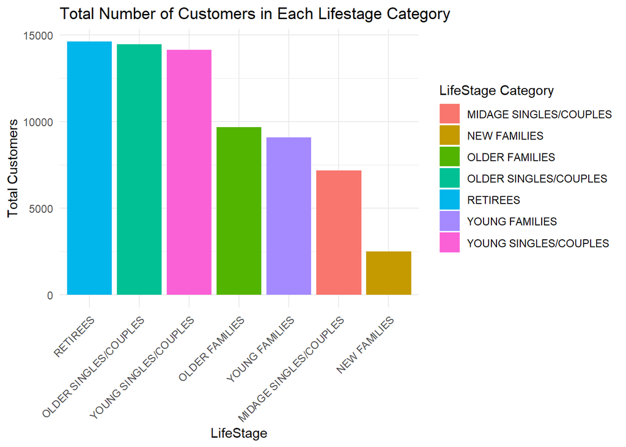

```r
Chip %>%
  group_by(LIFESTAGE, LYLTY_CARD_NBR) %>%
  summarise(total_count = n()) %>%
  group_by(LIFESTAGE) %>%
  summarise(total_count = n()) %>%
  ggplot(aes(x = reorder(LIFESTAGE, - total_count), y = total_count, fill = LIFESTAGE)) +
  geom_bar(stat = "identity") +
  scale_x_discrete(guide = guide_axis(angle = 45)) +
  labs(title = "Total Number of Customers in Each Lifestage Category", x = "LifeStage",
       y = "Total Customers", fill = "LifeStage Category") +
  theme_minimal()
```

The customers who are retirees, older singles/couples, and young singles/couples are the main groups that purchase the most chip products.

2. How many customers are in each group of the ‘PREMIUM_CUSTOMER’ category?

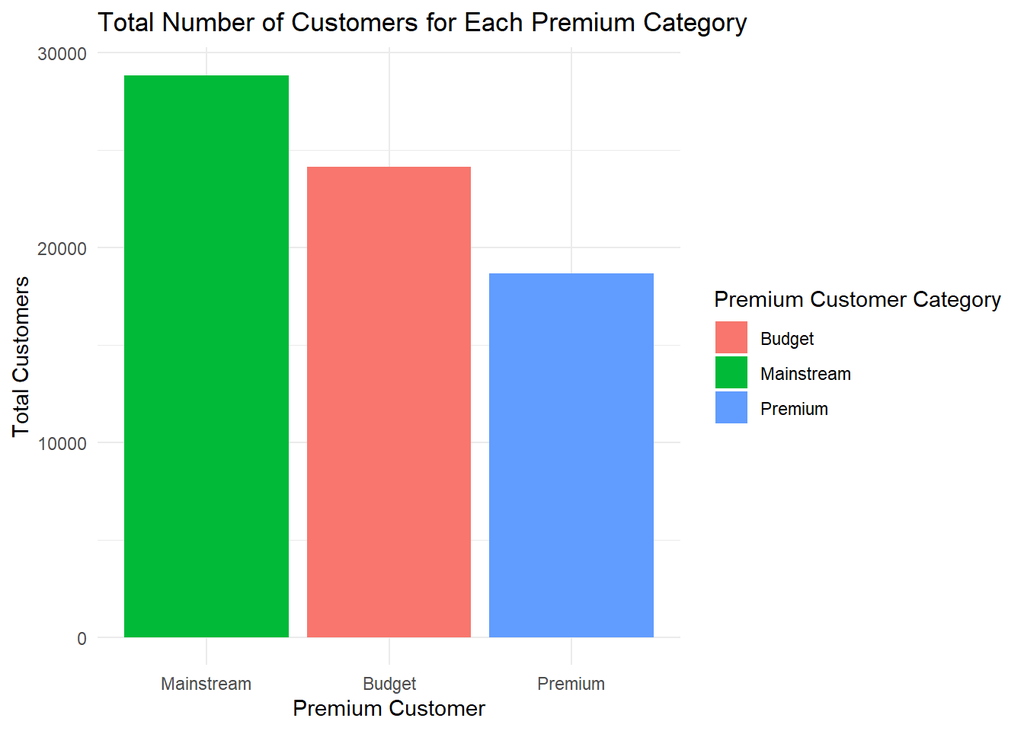

```r
Chip %>%
  group_by(PREMIUM_CUSTOMER, LYLTY_CARD_NBR) %>%
  summarise(total_count = n()) %>%
  group_by(PREMIUM_CUSTOMER) %>%
  summarise(total_count = n()) %>%
  ggplot(aes(x = reorder(PREMIUM_CUSTOMER,-total_count), y = total_count, fill = PREMIUM_CUSTOMER)) +
  geom_bar(stat = "identity") +
  labs(
    title = "Total Number of Customers for Each Premium Category", y = "Total Customers",
    x =  "Premium Customer", fill = "Premium Customer Category"
  ) +
  theme_minimal()
```

Most of the customers belong to the mainstream group, followed by the budget and premium groups.

Q3) How many customers are in each group of ‘LIFESTAGE’ and ‘PREMIUM_CUSTOMER’ category?

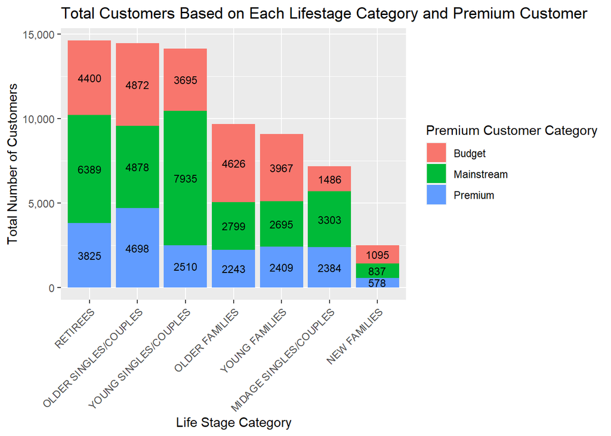

```r
Chip %>%
  group_by(LIFESTAGE, PREMIUM_CUSTOMER, LYLTY_CARD_NBR) %>%
  summarise(total_count = n()) %>%
  group_by(LIFESTAGE, PREMIUM_CUSTOMER) %>%
  summarise(total_count = n()) %>%
  ggplot(aes(x = reorder(LIFESTAGE, - total_count), y = total_count, fill = PREMIUM_CUSTOMER)) +
  geom_bar(stat = "identity") +
  geom_text(aes(label = total_count),
            position = position_stack(vjust = 0.5), size = 3, color = "black") +
  labs(
    title = "Total Customers Based on Each Lifestage Category and Premium Customer",
    x = "Life Stage Category",
    y = "Total Number of Customers",
    fill = "Premium Customer Category"
  ) +
  scale_y_continuous(labels = function(x) format(x, big.mark = ",", scientific = FALSE)) +
  theme(axis.text.x = element_text(angle = 45, hjust = 1))
```

Q4) What is the Total Chip Sales Based on Each Lifestage Category and Premium Customer?

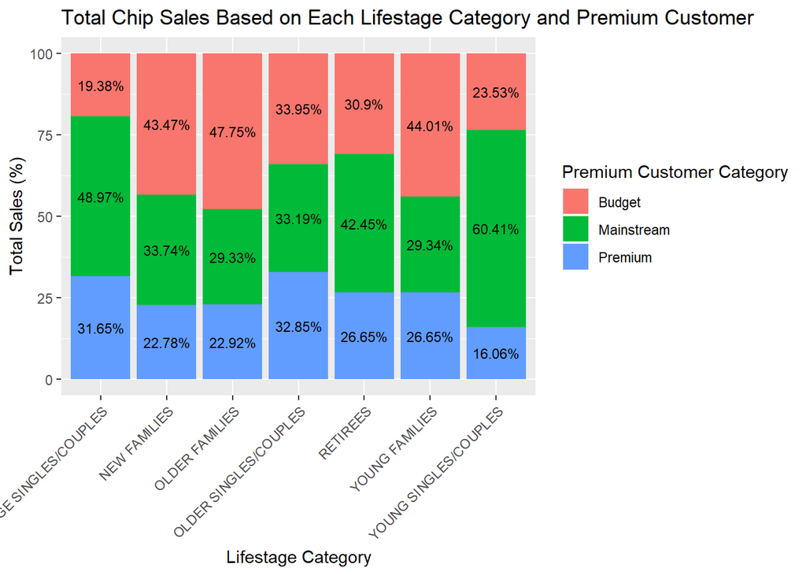

```r
Chip %>%
  group_by(LIFESTAGE,PREMIUM_CUSTOMER) %>%
  summarise(total_sales = sum(TOT_SALES, na.rm = TRUE)) %>%
  ungroup(PREMIUM_CUSTOMER) %>%
  mutate(percent_tot_sales = total_sales/sum(total_sales, na.rm = TRUE)*100) %>%
  ggplot(aes(x = LIFESTAGE, y = percent_tot_sales, fill = PREMIUM_CUSTOMER)) +
  geom_bar(stat = "identity") +
  geom_text(aes(label = paste0(round(percent_tot_sales,2),"%")),
            position = position_stack(vjust = 0.5), size = 3, color = "black") +
  labs(
    title = "Total Chip Sales Based on Each Lifestage Category and Premium Customer",
    x = "Lifestage Category",
    y = "Total Sales (%)",
    fill = "Premium Customer Category"
  ) +
  scale_y_continuous(labels = function(x) format(x, big.mark = ",", scientific = FALSE)) +
  theme(axis.text.x = element_text(angle = 45, hjust = 1))
```

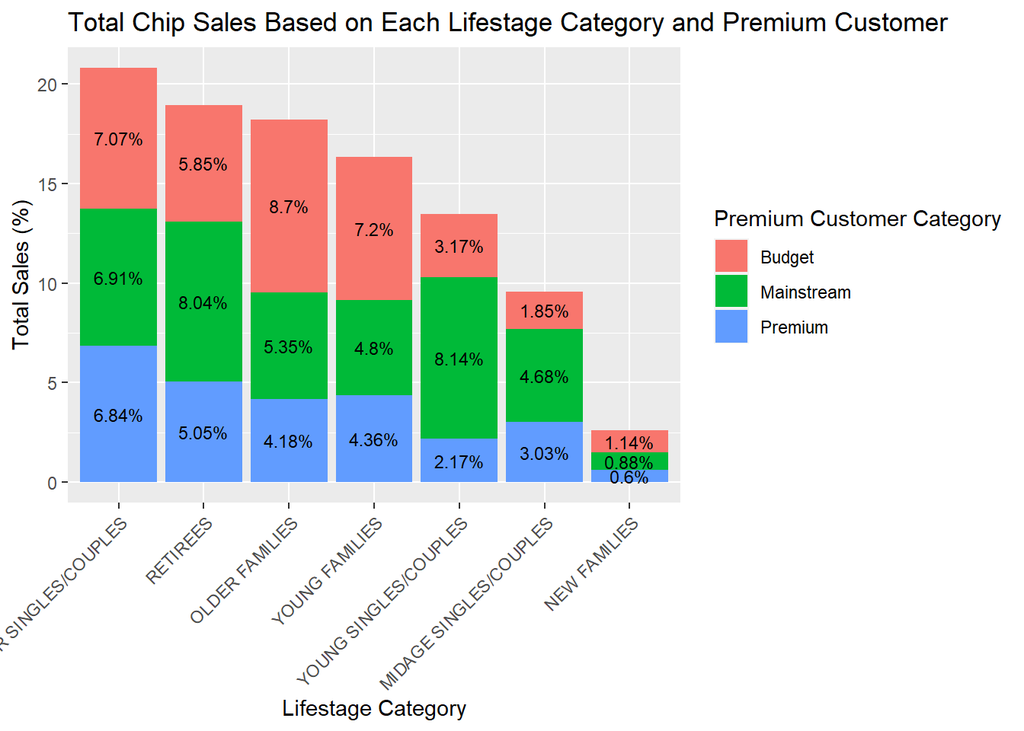

```r
Chip %>%
  group_by(LIFESTAGE,PREMIUM_CUSTOMER) %>%
  summarise(total_sales = sum(TOT_SALES, na.rm = TRUE)) %>%
  ungroup(PREMIUM_CUSTOMER, LIFESTAGE) %>%
  mutate(percent_tot_sales = total_sales/sum(total_sales, na.rm = TRUE)*100) %>%
  ggplot(aes(x = reorder(LIFESTAGE, - percent_tot_sales), y = percent_tot_sales, fill = PREMIUM_CUSTOMER)) +
  geom_bar(stat = "identity") +
  geom_text(aes(label = paste0(round(percent_tot_sales,2),"%")),
            position = position_stack(vjust = 0.5), size = 3, color = "black") +
  labs(
    title = "Total Chip Sales Based on Each Lifestage Category and Premium Customer",
    x = "Lifestage Category",
    y = "Total Sales (%)",
    fill = "Premium Customer Category"
  ) +
  scale_y_continuous(labels = function(x) format(x, big.mark = ",", scientific = FALSE)) +
  theme(axis.text.x = element_text(angle = 45, hjust = 1))
```

Q5) When did customers buy more than 2 products per transaction?

```r
Chip %>%
  filter(PROD_QTY > 2) %>%
  arrange(DATE, PROD_QTY) %>%
  group_by(DATE, PROD_QTY) %>%
  summarise(Total_Customer = n())
```

| DATE | PROD_QTY | Total_Customer |
| --- | --- | --- |
| 2018-07-08 | 3 | 1 |
| 2018-07-19 | 3 | 1 |
| 2018-08-14 | 3 | 38 |
| 2018-08-14 | 4 | 27 |
| 2018-08-14 | 5 | 21 |
| 2018-08-15 | 3 | 25 |
| 2018-08-15 | 4 | 33 |
| 2018-08-15 | 5 | 37 |
| 2018-08-16 | 3 | 25 |
| 2018-08-16 | 4 | 32 |

[output cut: 40 more lines]

Q6) How many customers repurchased chip products?

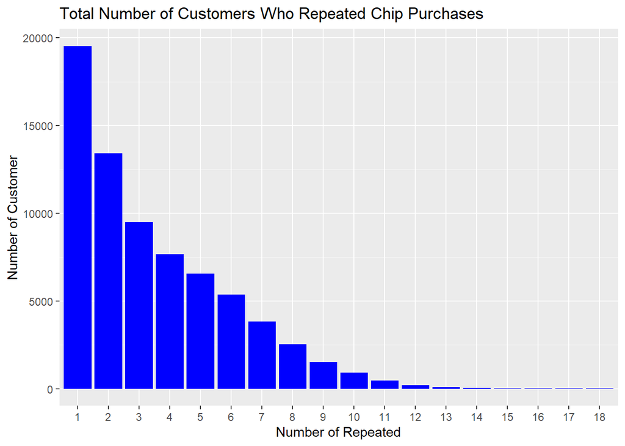

```r
Chip %>%
  group_by(LYLTY_CARD_NBR) %>%
  summarise(cus_count = n_distinct(DATE)) %>%
  ungroup() %>%
  group_by(factor = as.factor(cus_count)) %>%
  summarise(count = n()) %>%
  ggplot(aes(x = factor, y = count)) +
  geom_bar(stat = "identity", fill = "blue") +
  labs(
    title = "Total Number of Customers Who Repeated Chip Purchases",
    x = "Number of Repeated",
    y = "Number of Customer"
  )
```

Q7) How long until the customer buy chip product again?

```r
Chip %>%
  dplyr::select(LYLTY_CARD_NBR, DATE) %>%
  distinct(LYLTY_CARD_NBR, DATE) %>%
  arrange(LYLTY_CARD_NBR,DATE) %>%
  group_by(LYLTY_CARD_NBR) %>%
  mutate(Next_Buy = as.numeric(lead(DATE)- DATE)) %>%
  filter(Next_Buy != "NA days") %>%
  summary()
```

```
##  LYLTY_CARD_NBR         DATE               Next_Buy
##  Min.   :   1003   Min.   :2018-07-01   Min.   :  1.00
##  1st Qu.:  70227   1st Qu.:2018-09-10   1st Qu.: 18.00
##  Median : 130109   Median :2018-11-23   Median : 43.00
##  Mean   : 135247   Mean   :2018-11-29   Mean   : 60.54
##  3rd Qu.: 202344   3rd Qu.:2019-02-13   3rd Qu.: 85.00
##  Max.   :2370581   Max.   :2019-06-29   Max.   :360.00
```

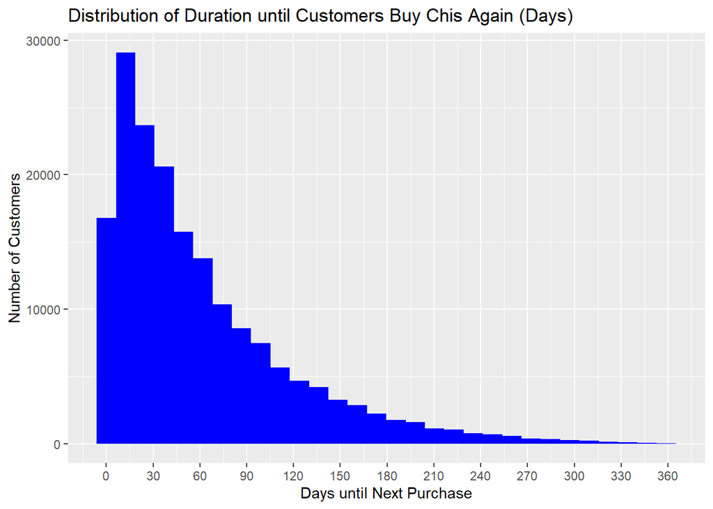

```r
Chip %>%
  dplyr::select(LYLTY_CARD_NBR, DATE) %>%
  distinct(LYLTY_CARD_NBR, DATE) %>%
  arrange(LYLTY_CARD_NBR,DATE) %>%
  group_by(LYLTY_CARD_NBR) %>%
  mutate(Next_Buy = as.numeric(lead(DATE)- DATE)) %>%
  filter(Next_Buy != "NA days") %>%
  ggplot(aes(x = Next_Buy)) +
  geom_histogram(fill = "blue") +
  labs(
    title = "Distribution of Duration until Customers Buy Chis Again (Days)",
    x = "Days until Next Purchase",
    y = "Number of Customers"
  ) +
  scale_x_continuous(breaks = seq(0, max(360, na.rm = TRUE), by = 30))
```

This analysis shows how many days pass before customers repurchase chip products. The summary gives the distribution details, while the histogram helps visualize the frequency of repurchase intervals.

Q8) The difference in total sales between family groups and single/couple groups

```r
t1 <- Chip %>%
  filter(LIFESTAGE %in% c("NEW FAMILIES","OLDER FAMILIES","YOUNG FAMILIES")) %>%
  pull(TOT_SALES)
t2 <- Chip %>%
  filter(LIFESTAGE %in% c("OLDER SINGLES/COUPLES","MIDAGE SINGLES/COUPLES","YOUNG SINGLES/COUPLES")) %>%
  pull(TOT_SALES)
var.test(t1, t2)
```

```
##
##  F test to compare two variances
##
## data:  t1 and t2
## F = 0.94467, num df = 93970, denom df = 110012, p-value < 2.2e-16
## alternative hypothesis: true ratio of variances is not equal to 1
## 95 percent confidence interval:
##  0.9331147 0.9563780
## sample estimates:
## ratio of variances
##          0.9446719
```

```r
t.test(t1, t2, var.equal = FALSE)
```

```
##
##  Welch Two Sample t-test
##
## data:  t1 and t2
## t = -4.6745, df = 200625, p-value = 2.949e-06
## alternative hypothesis: true difference in means is not equal to 0
## 95 percent confidence interval:
##  -0.07325305 -0.02997158
## sample estimates:
## mean of x mean of y
##  7.219946  7.271558
```

The mean total sales for family groups and single/couple groups are 7.219946 and 7.271558 respectively. The t-test result shows a statistically significant difference between the two groups, suggesting that single and couple households tend to spend more on chip products compared to families.

Q9) Do sales differ significantly between ‘PREMIUM_CUSTOMER’ groups?

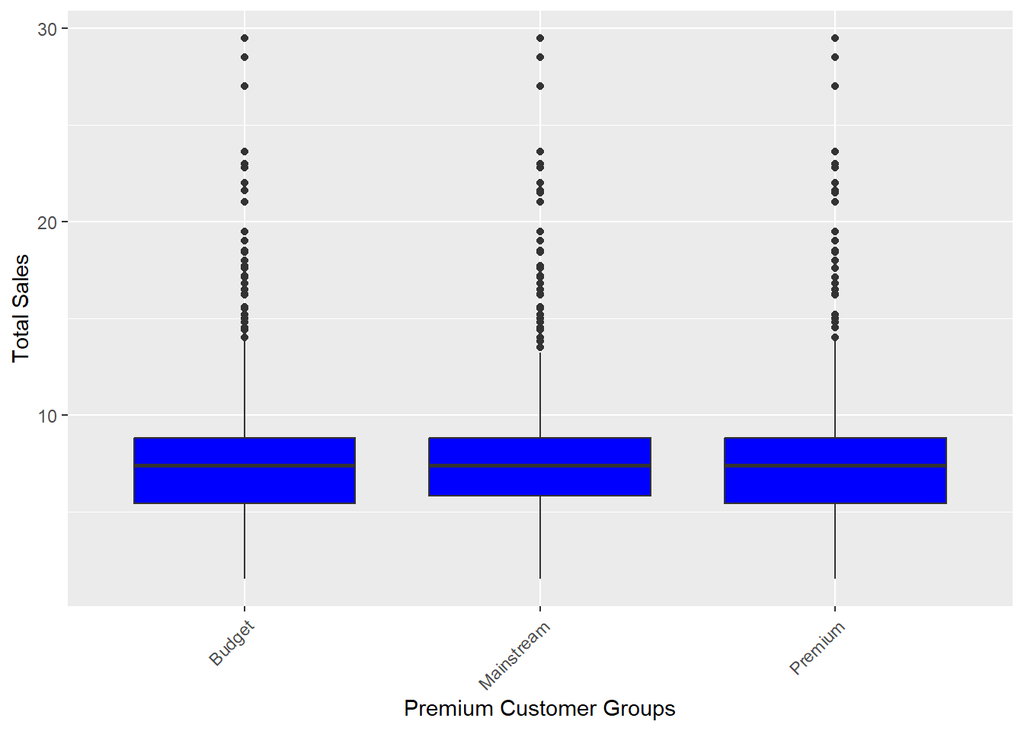

```r
Chip %>%
  ggplot(aes(x = PREMIUM_CUSTOMER, y = TOT_SALES)) +
  geom_boxplot(fill = "blue") +
  labs(
    x = "Premium Customer Groups",
    y = "Total Sales"
  ) +
  theme(axis.text.x = element_text(angle = 45, hjust = 1))
```

```r
Chip %>%
  group_by(PREMIUM_CUSTOMER) %>%
  summarise(mean = mean(TOT_SALES, na.rm = TRUE), sd = sd(TOT_SALES, na.rm = TRUE))
```

| PREMIUM_CUSTOMER | mean | sd |
| --- | --- | --- |
| Budget | 7.223785 | 2.501297 |
| Mainstream | 7.321973 | 2.475085 |
| Premium | 7.226957 | 2.502097 |

```r
leveneTest(TOT_SALES ~ PREMIUM_CUSTOMER, data = Chip)
```

|  | Df | F value | Pr(>F) |
| --- | --- | --- | --- |
| group | 2 | 13.83872 | 9.778023e-07 |
|  | 251155 | NA | NA |

```r
oneway.test(TOT_SALES ~ PREMIUM_CUSTOMER,
  data = Chip,
  var.equal = FALSE
)
```

```
##
##  One-way analysis of means (not assuming equal variances)
##
## data:  TOT_SALES and PREMIUM_CUSTOMER
## F = 45.159, num df = 2, denom df = 157781, p-value < 2.2e-16
```

```r
gamesHowellTest(TOT_SALES ~ PREMIUM_CUSTOMER, data = Chip %>% mutate(PREMIUM_CUSTOMER = as.factor(PREMIUM_CUSTOMER)))
```

```
##
##  Pairwise comparisons using Games-Howell test
```

```
## data: TOT_SALES by PREMIUM_CUSTOMER
```

```
##            Budget  Mainstream
## Mainstream 2.9e-14 -
## Premium    0.97    1.4e-13
```

```
##
## P value adjustment method: none
```

```
## alternative hypothesis: two.sided
```

The mean total sales for budget, mainstream, and premium groups are 7.223785, 7.321973, and 7.226957 respectively. ANOVA indicates that there is a significant difference in total sales among at least one of the groups. The Games-Howell post hoc test reveals that the mainstream group differs significantly from both budget and premium groups, while the budget and premium groups are not significantly different from each other. This suggests that mainstream customers tend to spend more on chip products.

Q10) Do total sales significantly differ between lifestage groups?

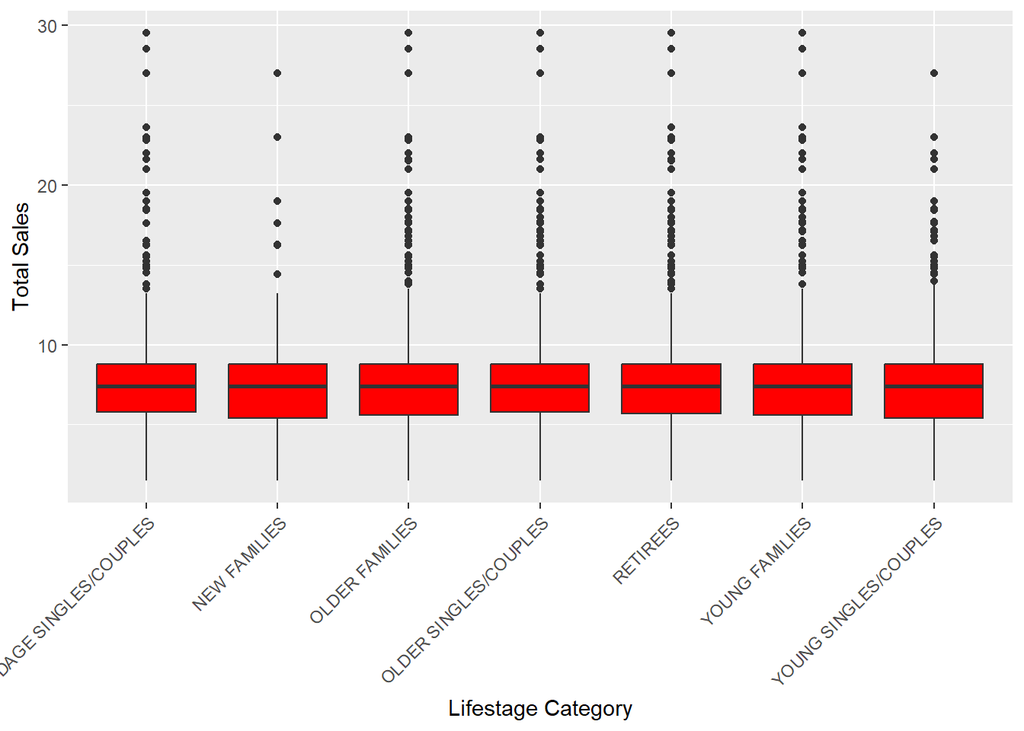

```r
Chip %>%
  ggplot(aes(x = LIFESTAGE, y = TOT_SALES)) +
  geom_boxplot(fill = "red") +
  labs(
    x = "Lifestage Category",
    y = "Total Sales"
  ) +
  theme(axis.text.x = element_text(angle = 45, hjust = 1))
```

```r
Chip %>%
  group_by(LIFESTAGE) %>%
  summarise(mean = mean(TOT_SALES, na.rm = TRUE), sd = sd(TOT_SALES, na.rm = TRUE))
```

| LIFESTAGE | mean | sd |
| --- | --- | --- |
| MIDAGE SINGLES/COUPLES | 7.319458 | 2.500093 |
| NEW FAMILIES | 7.238364 | 2.531573 |
| OLDER FAMILIES | 7.219485 | 2.446701 |
| OLDER SINGLES/COUPLES | 7.349681 | 2.479589 |
| RETIREES | 7.325675 | 2.493224 |
| YOUNG FAMILIES | 7.217520 | 2.446838 |
| YOUNG SINGLES/COUPLES | 7.121604 | 2.597440 |

```r
leveneTest(TOT_SALES ~ LIFESTAGE, data = Chip)
```

|  | Df | F value | Pr(>F) |
| --- | --- | --- | --- |
| group | 6 | 36.60346 | 1.312861e-44 |
|  | 251151 | NA | NA |

```r
oneway.test(TOT_SALES ~ LIFESTAGE,
  data = Chip,
  var.equal = FALSE
)
```

```
##
##  One-way analysis of means (not assuming equal variances)
##
## data:  TOT_SALES and LIFESTAGE
## F = 39.476, num df = 6, denom df = 62089, p-value < 2.2e-16
```

```r
gamesHowellTest(TOT_SALES ~ LIFESTAGE, data = Chip %>% mutate(LIFESTAGE= as.factor(LIFESTAGE)))
```

```
##
##  Pairwise comparisons using Games-Howell test
```

```
## data: TOT_SALES by LIFESTAGE
```

```
##                       MIDAGE SINGLES/COUPLES NEW FAMILIES OLDER FAMILIES
## NEW FAMILIES          0.240                  -            -
## OLDER FAMILIES        9.3e-06                0.998        -
## OLDER SINGLES/COUPLES 0.716                  0.013        8.1e-14
## RETIREES              1.000                  0.118        1.1e-09
## YOUNG FAMILIES        9.1e-06                0.996        1.000
## YOUNG SINGLES/COUPLES 7.6e-14                0.011        1.2e-06
##                       OLDER SINGLES/COUPLES RETIREES YOUNG FAMILIES
## NEW FAMILIES          -                     -        -
## OLDER FAMILIES        -                     -        -
## OLDER SINGLES/COUPLES -                     -        -
## RETIREES              0.735                 -        -
## YOUNG FAMILIES        9.4e-14               1.7e-09  -
## YOUNG SINGLES/COUPLES < 2e-16               1.1e-14  4.2e-06
```

```
##
## P value adjustment method: none
```

```
## alternative hypothesis: two.sided
```

Average Sales: The average total sales are fairly similar across all lifestage groups, ranging from 7.12 to 7.35.

Highest: Older Singles/Couples (7.35)

Lowest: Young Singles/Couples (7.12)

Statistical Differences (Games-Howell Test): Significant differences in total sales were mostly observed between:

Young Singles/Couples and almost every other group (very small p-values, e.g., <2e-16 vs Older Singles/Couples).

Older Families vs:

Older Singles/Couples (p = 8.1e-14)

Retirees (p = 1.1e-09)

Young Singles/Couples (p = 1.2e-06)

Midage Singles/Couples and:

Older Families (p = 9.3e-06)

Young Families (p = 9.1e-06)

Young Singles/Couples (p = 7.6e-14)

No Significant Differences were found among:

Midage Singles/Couples, Retirees, and Older Singles/Couples (p > 0.7)

New Families, Older Families, and Young Families (p = 0.99)

While the average total sales values are close across lifestage segments, Young Singles/Couples consistently show significantly lower sales compared to most other groups. On the other hand, Older and Retired groups tend to spend more, but not always at significantly higher levels.

Q11) Which brand is the most popular among different ‘LIFESTAGE’ and ‘PREMIUM_CUSTOMER’ groups?

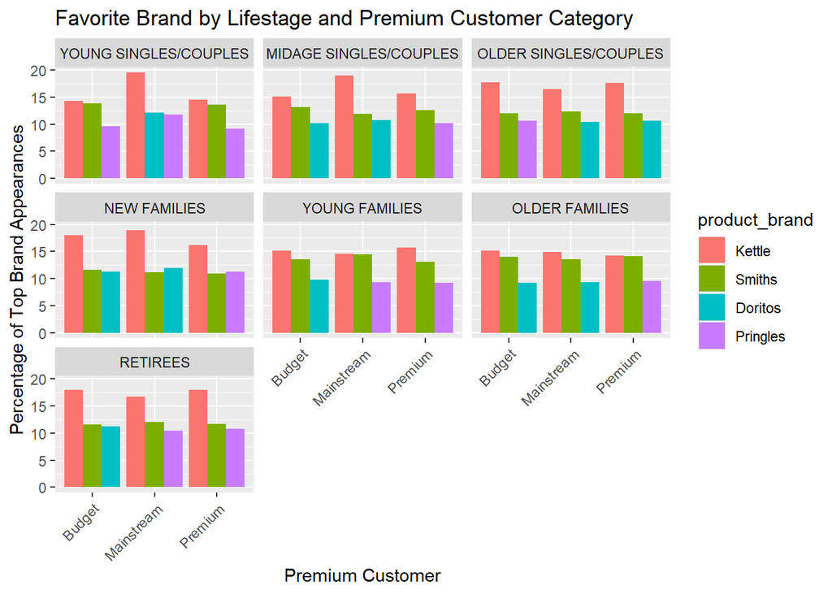

```r
Chip %>%
  group_by(LIFESTAGE,PREMIUM_CUSTOMER, product_brand) %>%
  summarise(total_count = sum(PROD_QTY)) %>%
  ungroup() %>%
  group_by(LIFESTAGE,PREMIUM_CUSTOMER) %>%
  mutate(total_percent = total_count/sum(total_count)*100) %>%
  slice_max(order_by = total_percent, n = 3) %>%
  ungroup() %>%
  mutate(
    product_brand = reorder(product_brand, -total_percent),
    LIFESTAGE= factor(LIFESTAGE,
           levels = c("YOUNG SINGLES/COUPLES", "MIDAGE SINGLES/COUPLES","OLDER SINGLES/COUPLES", "NEW FAMILIES","YOUNG FAMILIES", "OLDER FAMILIES", "RETIREES"))
    ) %>%
  ggplot(aes(x = PREMIUM_CUSTOMER, y = total_percent, fill = product_brand)) +
  geom_bar(position = "dodge", stat = "identity") +
  facet_wrap(~ LIFESTAGE) +
  labs(title = "Favorite Brand by Lifestage and Premium Customer Category",
       y = "Percentage of Top Brand Appearances",
       x = "Premium Customer") +
  theme(axis.text.x = element_text(angle = 45, hjust = 1))
```

Q12) What is the most popular chip product among ‘LIFESTAGE’ and ‘PREMIUM_CUSTOMER’ groups?

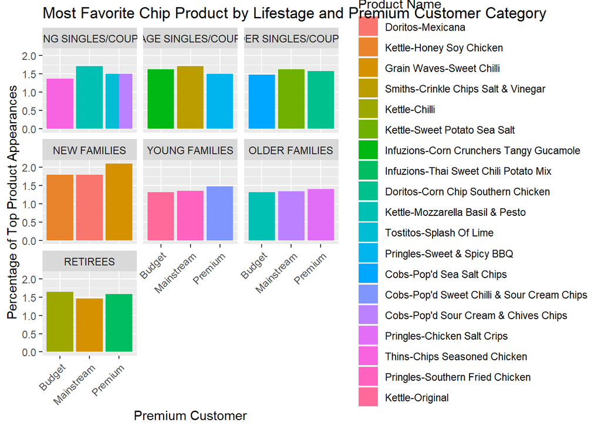

```r
Chip %>%
  mutate(product_name = paste(product_brand,product_name, sep = "-")) %>%
  group_by(LIFESTAGE,PREMIUM_CUSTOMER, product_name) %>%
  summarise(total_count = sum(PROD_QTY)) %>%
  ungroup() %>%
  group_by(LIFESTAGE,PREMIUM_CUSTOMER) %>%
  mutate(total_percent = total_count/sum(total_count)*100) %>%
  slice_max(order_by = total_percent, n = 1) %>%
  ungroup() %>%
  mutate(
    product_name = reorder(product_name, -total_percent),
    LIFESTAGE= factor(LIFESTAGE,
           levels = c("YOUNG SINGLES/COUPLES", "MIDAGE SINGLES/COUPLES","OLDER SINGLES/COUPLES", "NEW FAMILIES","YOUNG FAMILIES", "OLDER FAMILIES", "RETIREES"))
    ) %>%
  ggplot(aes(x = PREMIUM_CUSTOMER, y = total_percent, fill = product_name)) +
  geom_bar(position = "dodge", stat = "identity") +
  facet_wrap(~ LIFESTAGE) +
  labs(title = "Most Favorite Chip Product by Lifestage and Premium Customer Category",
       y = "Percentage of Top Product Appearances",
       x = "Premium Customer",
       fill = "Product Name") +
  theme(axis.text.x = element_text(angle = 45, hjust = 1))
```

This chart highlights the most preferred chip product in each combination of ‘LIFESTAGE’ and ‘PREMIUM_CUSTOMER’ category. The product name is a combination of the brand and item name, making it easy to see specific preferences. Each bar shows the product with the highest share of purchases within that segment.

# Assosiacion Rule Analysis

1. Association Rule Analysis: Brand Loyalty and Relationships

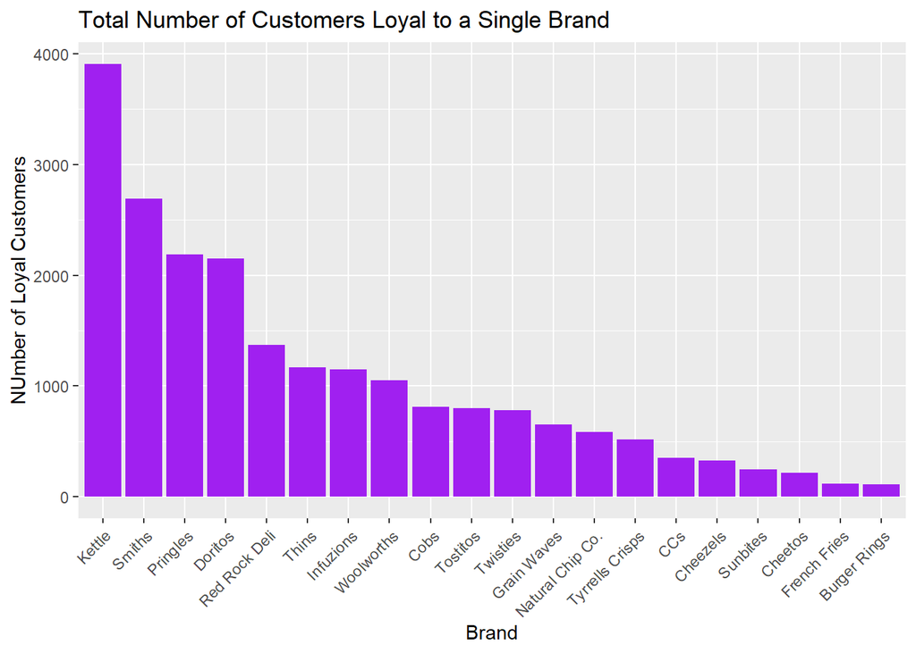

```r
Chip %>%
  group_by(LYLTY_CARD_NBR) %>%
  mutate(tot_brand = n_distinct(product_brand)) %>%
  filter(tot_brand == 1) %>%
  ungroup() %>%
  group_by(product_brand) %>%
  summarise(loyal = n_distinct(LYLTY_CARD_NBR)) %>%
  ggplot(aes(x = reorder(product_brand, - loyal ), y = loyal)) +
  geom_bar(stat = "identity", fill = "purple") +
  labs(
    title = "Total Number of Customers Loyal to a Single Brand",
    x = "Brand",
    y = "NUmber of Loyal Customers"
  ) +
  theme(axis.text.x = element_text(angle = 45, hjust = 1))
```

```r
Chip %>%
  group_by(LYLTY_CARD_NBR) %>%
  summarise(tot_uniq_brand = n_distinct(product_brand)) %>%
  ungroup() %>%
  summarise(percent_customer = n_distinct(LYLTY_CARD_NBR[tot_uniq_brand >1])/n_distinct(LYLTY_CARD_NBR)*100)
```

| percent_customer |
| --- |
| 70.41076 |

```r
Chip %>%
  group_by(LYLTY_CARD_NBR, LIFESTAGE, PREMIUM_CUSTOMER) %>%
  summarise(tot_uniq_brand = n_distinct(product_brand)) %>%
  ungroup() %>%
  group_by(LIFESTAGE, PREMIUM_CUSTOMER) %>%
  summarise(percent_customer = n_distinct(LYLTY_CARD_NBR[tot_uniq_brand >1])/n_distinct(LYLTY_CARD_NBR)*100)
```

| LIFESTAGE | PREMIUM_CUSTOMER | percent_customer |
| --- | --- | --- |
| MIDAGE SINGLES/COUPLES | Budget | 68.84253 |
| MIDAGE SINGLES/COUPLES | Mainstream | 72.78232 |
| MIDAGE SINGLES/COUPLES | Premium | 67.82718 |
| NEW FAMILIES | Budget | 62.28311 |
| NEW FAMILIES | Mainstream | 64.99403 |
| NEW FAMILIES | Premium | 68.68512 |
| OLDER FAMILIES | Budget | 77.36706 |
| OLDER FAMILIES | Mainstream | 77.84923 |
| OLDER FAMILIES | Premium | 77.17343 |
| OLDER SINGLES/COUPLES | Budget | 75.49261 |

[output cut: 11 more lines]

```r
basket_data <- Chip %>%
  group_by(LYLTY_CARD_NBR) %>%
  summarise(items = list(unique(product_brand)))
```

```r
trans_list <- as(basket_data$items, "transactions")
```

```r
rules <- apriori(trans_list, parameter = list(supp = 0.01, conf = 0.1), appearance = list(lhs = "Kettle", default = "rhs"))
```

```
## Apriori
##
## Parameter specification:
##  confidence minval smax arem  aval originalSupport maxtime support minlen
##         0.1    0.1    1 none FALSE            TRUE       5    0.01      1
##  maxlen target  ext
##      10  rules TRUE
##
## Algorithmic control:
##  filter tree heap memopt load sort verbose
##     0.1 TRUE TRUE  FALSE TRUE    2    TRUE
##
## Absolute minimum support count: 716
##
## set item appearances ...[1 item(s)] done [0.00s].
## set transactions ...[20 item(s), 71624 transaction(s)] done [0.03s].
## sorting and recoding items ... [20 item(s)] done [0.00s].
## creating transaction tree ... done [0.04s].
## checking subsets of size 1 2 done [0.01s].
## writing ... [22 rule(s)] done [0.00s].
## creating S4 object  ... done [0.00s].
```

```r
sorted_rules <- sort(rules, by = "lift", decreasing = TRUE)
inspect(sorted_rules[1:10])
```

```
##      lhs         rhs           support    confidence coverage  lift     count
## [1]  {Kettle} => {Cobs}        0.06051044 0.1436241  0.4213113 1.147583 4334
## [2]  {Kettle} => {Twisties}    0.05847202 0.1387858  0.4213113 1.138778 4188
## [3]  {Kettle} => {Tostitos}    0.05805317 0.1377916  0.4213113 1.126620 4158
## [4]  {Kettle} => {Thins}       0.08304479 0.1971103  0.4213113 1.121263 5948
## [5]  {Kettle} => {Doritos}     0.13577851 0.3222760  0.4213113 1.114837 9725
## [6]  {Kettle} => {Infuzions}   0.08261197 0.1960830  0.4213113 1.111096 5917
## [7]  {Kettle} => {Pringles}    0.13481515 0.3199894  0.4213113 1.109499 9656
## [8]  {Kettle} => {Grain Waves} 0.04705127 0.1116782  0.4213113 1.104507 3370
## [9]  {Kettle} => {Smiths}      0.13790070 0.3273131  0.4213113 1.012896 9877
## [10] {}       => {Grain Waves} 0.10111136 0.1011114  1.0000000 1.000000 7242
```

```r
rules <- apriori(trans_list, parameter = list(supp = 0.01, conf = 0.1), appearance = list(lhs = "Smiths", default = "rhs"))
```

```
## Apriori
##
## Parameter specification:
##  confidence minval smax arem  aval originalSupport maxtime support minlen
##         0.1    0.1    1 none FALSE            TRUE       5    0.01      1
##  maxlen target  ext
##      10  rules TRUE
##
## Algorithmic control:
##  filter tree heap memopt load sort verbose
##     0.1 TRUE TRUE  FALSE TRUE    2    TRUE
##
## Absolute minimum support count: 716
##
## set item appearances ...[1 item(s)] done [0.00s].
## set transactions ...[20 item(s), 71624 transaction(s)] done [0.02s].
## sorting and recoding items ... [20 item(s)] done [0.01s].
## creating transaction tree ... done [0.05s].
## checking subsets of size 1 2 done [0.00s].
## writing ... [23 rule(s)] done [0.00s].
## creating S4 object  ... done [0.00s].
```

```r
sorted_rules <- sort(rules, by = "lift", decreasing = TRUE)
inspect(sorted_rules[1:10])
```

```
##      lhs         rhs                support    confidence coverage  lift
## [1]  {Smiths} => {Natural Chip Co.} 0.04883838 0.1511342  0.3231459 1.621212
## [2]  {Smiths} => {Red Rock Deli}    0.09908690 0.3066321  0.3231459 1.600745
## [3]  {Smiths} => {Woolworths}       0.07866078 0.2434219  0.3231459 1.586284
## [4]  {Smiths} => {Grain Waves}      0.03733385 0.1155325  0.3231459 1.142626
## [5]  {Smiths} => {Thins}            0.06211605 0.1922229  0.3231459 1.093462
## [6]  {Smiths} => {Infuzions}        0.06185078 0.1914020  0.3231459 1.084571
## [7]  {Smiths} => {Tostitos}         0.04156428 0.1286239  0.3231459 1.051662
## [8]  {Smiths} => {Pringles}         0.09626661 0.2979045  0.3231459 1.032924
## [9]  {Smiths} => {Doritos}          0.09640623 0.2983366  0.3231459 1.032024
## [10] {Smiths} => {Cobs}             0.04134089 0.1279326  0.3231459 1.022205
##      count
## [1]  3498
## [2]  7097
## [3]  5634
## [4]  2674
## [5]  4449
## [6]  4430
## [7]  2977
## [8]  6895
## [9]  6905
## [10] 2961
```

```r
rules <- apriori(trans_list, parameter = list(supp = 0.01, conf = 0.1), appearance = list(lhs = "Doritos", default = "rhs"))
```

```
## Apriori
##
## Parameter specification:
##  confidence minval smax arem  aval originalSupport maxtime support minlen
##         0.1    0.1    1 none FALSE            TRUE       5    0.01      1
##  maxlen target  ext
##      10  rules TRUE
##
## Algorithmic control:
##  filter tree heap memopt load sort verbose
##     0.1 TRUE TRUE  FALSE TRUE    2    TRUE
##
## Absolute minimum support count: 716
##
## set item appearances ...[1 item(s)] done [0.00s].
## set transactions ...[20 item(s), 71624 transaction(s)] done [0.03s].
## sorting and recoding items ... [20 item(s)] done [0.00s].
## creating transaction tree ... done [0.04s].
## checking subsets of size 1 2 done [0.00s].
## writing ... [22 rule(s)] done [0.00s].
## creating S4 object  ... done [0.01s].
```

```r
sorted_rules <- sort(rules, by = "lift", decreasing = TRUE)
inspect(sorted_rules[1:10])
```

```
##      lhs          rhs             support    confidence coverage  lift
## [1]  {Doritos} => {Twisties}      0.04088015 0.1414151  0.2890791 1.160352
## [2]  {Doritos} => {Infuzions}     0.05917011 0.2046849  0.2890791 1.159838
## [3]  {Doritos} => {Cobs}          0.04195521 0.1451340  0.2890791 1.159647
## [4]  {Doritos} => {Thins}         0.05820675 0.2013523  0.2890791 1.145394
## [5]  {Doritos} => {Tostitos}      0.04019602 0.1390485  0.2890791 1.136896
## [6]  {Doritos} => {Pringles}      0.09408857 0.3254769  0.2890791 1.128526
## [7]  {Doritos} => {Kettle}        0.13577851 0.4696933  0.2890791 1.114837
## [8]  {Doritos} => {Grain Waves}   0.03183291 0.1101183  0.2890791 1.089080
## [9]  {Doritos} => {Smiths}        0.09640623 0.3334943  0.2890791 1.032024
## [10] {Doritos} => {Red Rock Deli} 0.05576343 0.1929003  0.2890791 1.007018
##      count
## [1]  2928
## [2]  4238
## [3]  3005
## [4]  4169
## [5]  2879
## [6]  6739
## [7]  9725
## [8]  2280
## [9]  6905
## [10] 3994
```

```r
rules <- apriori(trans_list, parameter = list(supp = 0.01, conf = 0.1), appearance = list(lhs = "Pringles", default = "rhs"))
```

```
## Apriori
##
## Parameter specification:
##  confidence minval smax arem  aval originalSupport maxtime support minlen
##         0.1    0.1    1 none FALSE            TRUE       5    0.01      1
##  maxlen target  ext
##      10  rules TRUE
##
## Algorithmic control:
##  filter tree heap memopt load sort verbose
##     0.1 TRUE TRUE  FALSE TRUE    2    TRUE
##
## Absolute minimum support count: 716
##
## set item appearances ...[1 item(s)] done [0.00s].
## set transactions ...[20 item(s), 71624 transaction(s)] done [0.03s].
## sorting and recoding items ... [20 item(s)] done [0.00s].
## creating transaction tree ... done [0.04s].
## checking subsets of size 1 2 done [0.00s].
## writing ... [23 rule(s)] done [0.00s].
## creating S4 object  ... done [0.01s].
```

```r
sorted_rules <- sort(rules, by = "lift", decreasing = TRUE)
inspect(sorted_rules[1:10])
```

```
##      lhs           rhs               support    confidence coverage  lift
## [1]  {Pringles} => {Tyrrells Crisps} 0.02891489 0.1002566  0.2884089 1.175442
## [2]  {Pringles} => {Cobs}            0.04174578 0.1447451  0.2884089 1.156540
## [3]  {Pringles} => {Twisties}        0.04029376 0.1397105  0.2884089 1.146366
## [4]  {Pringles} => {Tostitos}        0.04034960 0.1399041  0.2884089 1.143892
## [5]  {Pringles} => {Infuzions}       0.05816486 0.2016750  0.2884089 1.142782
## [6]  {Pringles} => {Doritos}         0.09408857 0.3262332  0.2884089 1.128526
## [7]  {Pringles} => {Thins}           0.05715961 0.1981895  0.2884089 1.127402
## [8]  {Pringles} => {Grain Waves}     0.03283815 0.1138597  0.2884089 1.126082
## [9]  {Pringles} => {Kettle}          0.13481515 0.4674444  0.2884089 1.109499
## [10] {Pringles} => {Smiths}          0.09626661 0.3337852  0.2884089 1.032924
##      count
## [1]  2071
## [2]  2990
## [3]  2886
## [4]  2890
## [5]  4166
## [6]  6739
## [7]  4094
## [8]  2352
## [9]  9656
## [10] 6895
```

2. Association Rule Analysis: Chip Products Loyalty and Relationships

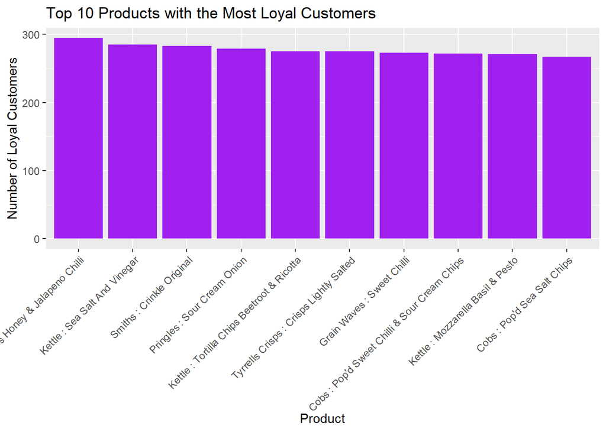

```r
Chip %>%
  group_by(LYLTY_CARD_NBR) %>%
  mutate(product_name = paste(product_brand, product_name, sep = " : "),tot_prod = n_distinct(product_name)) %>%
  filter(tot_prod == 1) %>%
  ungroup() %>%
  group_by(product_name) %>%
  summarise(loyal = n_distinct(LYLTY_CARD_NBR)) %>%
  ungroup() %>%
  slice_max(order_by = loyal, n = 10) %>%
  ggplot(aes(x = reorder(product_name, - loyal ), y = loyal)) +
  geom_bar(stat = "identity", fill = "purple") +
  labs(
    title = "Top 10 Products with the Most Loyal Customers",
    x = "Product",
    y = "Number of Loyal Customers"
  ) +
  theme(axis.text.x = element_text(angle = 45, hjust = 1))
```

```r
Chip %>%
  group_by(LYLTY_CARD_NBR) %>%
  summarise(tot_uniq_prod = n_distinct(product_name)) %>%
  ungroup() %>%
  summarise(percent_customer = n_distinct(LYLTY_CARD_NBR[tot_uniq_prod >1])/n_distinct(LYLTY_CARD_NBR)*100)
```

| percent_customer |
| --- |
| 72.49805 |

```r
Chip %>%
  group_by(LYLTY_CARD_NBR, LIFESTAGE, PREMIUM_CUSTOMER) %>%
  summarise(tot_uniq_prod = n_distinct(product_name)) %>%
  ungroup() %>%
  group_by(LIFESTAGE, PREMIUM_CUSTOMER) %>%
  summarise(percent_customer = n_distinct(LYLTY_CARD_NBR[tot_uniq_prod >1])/n_distinct(LYLTY_CARD_NBR)*100)
```

| LIFESTAGE | PREMIUM_CUSTOMER | percent_customer |
| --- | --- | --- |
| MIDAGE SINGLES/COUPLES | Budget | 70.59219 |
| MIDAGE SINGLES/COUPLES | Mainstream | 74.71995 |
| MIDAGE SINGLES/COUPLES | Premium | 69.96644 |
| NEW FAMILIES | Budget | 64.56621 |
| NEW FAMILIES | Mainstream | 67.38351 |
| NEW FAMILIES | Premium | 71.10727 |
| OLDER FAMILIES | Budget | 79.00994 |
| OLDER FAMILIES | Mainstream | 79.52840 |
| OLDER FAMILIES | Premium | 79.22425 |
| OLDER SINGLES/COUPLES | Budget | 77.19622 |

[output cut: 11 more lines]

```r
basket_data <- Chip %>%
  group_by(LYLTY_CARD_NBR) %>%
  mutate(product_name = paste(product_brand, product_name, sep = " : ")) %>%
  summarise(items = list(unique(product_name)))
```

```r
trans_list <- as(basket_data$items, "transactions")
```

```r
rules <- apriori(trans_list, parameter = list(supp = 0.001, conf = 0.05), appearance = list(lhs = "Kettle : Mozzarella Basil & Pesto", default = "rhs"))
```

```
## Apriori
##
## Parameter specification:
##  confidence minval smax arem  aval originalSupport maxtime support minlen
##        0.05    0.1    1 none FALSE            TRUE       5   0.001      1
##  maxlen target  ext
##      10  rules TRUE
##
## Algorithmic control:
##  filter tree heap memopt load sort verbose
##     0.1 TRUE TRUE  FALSE TRUE    2    TRUE
##
## Absolute minimum support count: 71
##
## set item appearances ...[1 item(s)] done [0.00s].
## set transactions ...[108 item(s), 71624 transaction(s)] done [0.04s].
## sorting and recoding items ... [108 item(s)] done [0.00s].
## creating transaction tree ... done [0.05s].
## checking subsets of size 1 2 done [0.00s].
## writing ... [33 rule(s)] done [0.00s].
## creating S4 object  ... done [0.01s].
```

```r
sorted_rules <- sort(rules, by = "lift", decreasing = TRUE)
inspect(sorted_rules[1:10])
```

```
##      lhs                                    rhs                                              support confidence   coverage     lift count
## [1]  {Kettle : Mozzarella Basil & Pesto} => {Kettle : Original}                          0.002638780 0.05878694 0.04488719 1.366620   189
## [2]  {Kettle : Mozzarella Basil & Pesto} => {Tostitos : Smoked Chipotle}                 0.002596895 0.05785381 0.04488719 1.351948   186
## [3]  {Kettle : Mozzarella Basil & Pesto} => {Kettle : Sensations Camembert & Fig}        0.002638780 0.05878694 0.04488719 1.341796   189
## [4]  {Kettle : Mozzarella Basil & Pesto} => {Infuzions : Corn Crunchers Tangy Gucamole}  0.002568971 0.05723173 0.04488719 1.335668   184
## [5]  {Kettle : Mozzarella Basil & Pesto} => {Kettle : Tortilla Chips Beetroot & Ricotta} 0.002541048 0.05660964 0.04488719 1.321581   182
## [6]  {Kettle : Mozzarella Basil & Pesto} => {Doritos : Corn Chip Southern Chicken}       0.002499162 0.05567652 0.04488719 1.288457   179
## [7]  {Kettle : Mozzarella Basil & Pesto} => {Pringles : Mystery Flavour}                 0.002443315 0.05443235 0.04488719 1.287537   175
## [8]  {Kettle : Mozzarella Basil & Pesto} => {Tyrrells Crisps : Crisps Ched & Chives}     0.002541048 0.05660964 0.04488719 1.274233   182
## [9]  {Kettle : Mozzarella Basil & Pesto} => {Twisties : Cheese}                          0.002401430 0.05349922 0.04488719 1.268397   172
## [10] {Kettle : Mozzarella Basil & Pesto} => {Thins : Potato Chips Hot & Spicy}           0.002499162 0.05567652 0.04488719 1.264355   179
```

```r
rules <- apriori(trans_list, parameter = list(supp = 0.001, conf = 0.05), appearance = list(lhs = "Kettle : Tortilla Chips Honey & Jalapeno Chilli", default = "rhs"))
```

```
## Apriori
##
## Parameter specification:
##  confidence minval smax arem  aval originalSupport maxtime support minlen
##        0.05    0.1    1 none FALSE            TRUE       5   0.001      1
##  maxlen target  ext
##      10  rules TRUE
##
## Algorithmic control:
##  filter tree heap memopt load sort verbose
##     0.1 TRUE TRUE  FALSE TRUE    2    TRUE
##
## Absolute minimum support count: 71
##
## set item appearances ...[1 item(s)] done [0.00s].
## set transactions ...[108 item(s), 71624 transaction(s)] done [0.04s].
## sorting and recoding items ... [108 item(s)] done [0.01s].
## creating transaction tree ... done [0.05s].
## checking subsets of size 1 2 done [0.01s].
## writing ... [36 rule(s)] done [0.00s].
## creating S4 object  ... done [0.01s].
```

```r
sorted_rules <- sort(rules, by = "lift", decreasing = TRUE)
inspect(sorted_rules[1:10])
```

```
##      lhs                                                  rhs                                                support confidence   coverage     lift count
## [1]  {Kettle : Tortilla Chips Honey & Jalapeno Chilli} => {Doritos : Cheese Supreme}                     0.002708589 0.06037971 0.04485927 1.445883   194
## [2]  {Kettle : Tortilla Chips Honey & Jalapeno Chilli} => {Cobs : Pop'd Sour Cream & Chives Chips}       0.002764437 0.06162465 0.04485927 1.433519   198
## [3]  {Kettle : Tortilla Chips Honey & Jalapeno Chilli} => {Pringles : Southern Fried Chicken}            0.002596895 0.05788982 0.04485927 1.382100   186
## [4]  {Kettle : Tortilla Chips Honey & Jalapeno Chilli} => {Infuzions : Sour Cream & Herbs Veggie Straws} 0.002624818 0.05851229 0.04485927 1.376317   188
## [5]  {Kettle : Tortilla Chips Honey & Jalapeno Chilli} => {Smiths : Crinkle Chip Original Big Bag}       0.002680666 0.05975724 0.04485927 1.359178   192
## [6]  {Kettle : Tortilla Chips Honey & Jalapeno Chilli} => {Tostitos : Splash Of Lime}                    0.002680666 0.05975724 0.04485927 1.352735   192
## [7]  {Kettle : Tortilla Chips Honey & Jalapeno Chilli} => {Doritos : Corn Chips Cheese Supreme}          0.002652742 0.05913477 0.04485927 1.351458   190
## [8]  {Kettle : Tortilla Chips Honey & Jalapeno Chilli} => {Thins : Potato Chips Hot & Spicy}             0.002666704 0.05944600 0.04485927 1.349956   191
## [9]  {Kettle : Tortilla Chips Honey & Jalapeno Chilli} => {Doritos : Corn Chip Supreme}                  0.002513124 0.05602241 0.04485927 1.289794   180
## [10] {Kettle : Tortilla Chips Honey & Jalapeno Chilli} => {Pringles : Mystery Flavour}                   0.002429353 0.05415500 0.04485927 1.280977   174
```

```r
rules <- apriori(trans_list, parameter = list(supp = 0.001, conf = 0.05), appearance = list(lhs = "Cobs : Pop'd Sea Salt Chips", default = "rhs"))
```

```
## Apriori
##
## Parameter specification:
##  confidence minval smax arem  aval originalSupport maxtime support minlen
##        0.05    0.1    1 none FALSE            TRUE       5   0.001      1
##  maxlen target  ext
##      10  rules TRUE
##
## Algorithmic control:
##  filter tree heap memopt load sort verbose
##     0.1 TRUE TRUE  FALSE TRUE    2    TRUE
##
## Absolute minimum support count: 71
##
## set item appearances ...[1 item(s)] done [0.00s].
## set transactions ...[108 item(s), 71624 transaction(s)] done [0.04s].
## sorting and recoding items ... [108 item(s)] done [0.00s].
## creating transaction tree ... done [0.04s].
## checking subsets of size 1 2 done [0.01s].
## writing ... [40 rule(s)] done [0.00s].
## creating S4 object  ... done [0.01s].
```

```r
sorted_rules <- sort(rules, by = "lift", decreasing = TRUE)
inspect(sorted_rules[1:10])
```

```
##      lhs                              rhs                                           support confidence  coverage     lift count
## [1]  {Cobs : Pop'd Sea Salt Chips} => {Kettle : Sensations BBQ & Maple}         0.002555009 0.05743879 0.0444823 1.366776   183
## [2]  {Cobs : Pop'd Sea Salt Chips} => {Pringles : Salt Vinegar}                 0.002527086 0.05681105 0.0444823 1.342916   181
## [3]  {Cobs : Pop'd Sea Salt Chips} => {Pringles : Mystery Flavour}              0.002513124 0.05649718 0.0444823 1.336378   180
## [4]  {Cobs : Pop'd Sea Salt Chips} => {Tyrrells Crisps : Crisps Lightly Salted} 0.002513124 0.05649718 0.0444823 1.313390   180
## [5]  {Cobs : Pop'd Sea Salt Chips} => {Twisties : Chicken}                      0.002499162 0.05618330 0.0444823 1.308216   179
## [6]  {Cobs : Pop'd Sea Salt Chips} => {Kettle : Chilli}                         0.002401430 0.05398619 0.0444823 1.307645   172
## [7]  {Cobs : Pop'd Sea Salt Chips} => {Kettle : Sea Salt And Vinegar}           0.002499162 0.05618330 0.0444823 1.304823   179
## [8]  {Cobs : Pop'd Sea Salt Chips} => {Kettle : Honey Soy Chicken}              0.002485200 0.05586943 0.0444823 1.298796   178
## [9]  {Cobs : Pop'd Sea Salt Chips} => {Cheezels : Cheese}                       0.002457277 0.05524168 0.0444823 1.292594   176
## [10] {Cobs : Pop'd Sea Salt Chips} => {Doritos : Corn Chips Cheese Supreme}     0.002513124 0.05649718 0.0444823 1.291179   180
```

```r
rules <- apriori(trans_list, parameter = list(supp = 0.001, conf = 0.05), appearance = list(lhs = "Tyrrells Crisps : Crisps Ched & Chives", default = "rhs"))
```

```
## Apriori
##
## Parameter specification:
##  confidence minval smax arem  aval originalSupport maxtime support minlen
##        0.05    0.1    1 none FALSE            TRUE       5   0.001      1
##  maxlen target  ext
##      10  rules TRUE
##
## Algorithmic control:
##  filter tree heap memopt load sort verbose
##     0.1 TRUE TRUE  FALSE TRUE    2    TRUE
##
## Absolute minimum support count: 71
##
## set item appearances ...[1 item(s)] done [0.00s].
## set transactions ...[108 item(s), 71624 transaction(s)] done [0.03s].
## sorting and recoding items ... [108 item(s)] done [0.00s].
## creating transaction tree ... done [0.04s].
## checking subsets of size 1 2 done [0.01s].
## writing ... [40 rule(s)] done [0.00s].
## creating S4 object  ... done [0.01s].
```

```r
sorted_rules <- sort(rules, by = "lift", decreasing = TRUE)
inspect(sorted_rules[1:10])
```

```
##      lhs                                         rhs                                           support confidence   coverage     lift count
## [1]  {Tyrrells Crisps : Crisps Ched & Chives} => {Tostitos : Lightly Salted}               0.002596895 0.05845380 0.04442645 1.389083   186
## [2]  {Tyrrells Crisps : Crisps Ched & Chives} => {Thins : Potato Chips Hot & Spicy}        0.002694627 0.06065368 0.04442645 1.377381   193
## [3]  {Tyrrells Crisps : Crisps Ched & Chives} => {Doritos : Corn Chips Nacho Cheese}       0.002610857 0.05876807 0.04442645 1.365738   187
## [4]  {Tyrrells Crisps : Crisps Ched & Chives} => {Twisties : Cheese Burger}                0.002610857 0.05876807 0.04442645 1.361321   187
## [5]  {Tyrrells Crisps : Crisps Ched & Chives} => {Infuzions : Thai Sweet Chili Potato Mix} 0.002638780 0.05939661 0.04442645 1.352694   189
## [6]  {Tyrrells Crisps : Crisps Ched & Chives} => {Grain Waves : Sweet Chilli}              0.002513124 0.05656820 0.04442645 1.320613   180
## [7]  {Tyrrells Crisps : Crisps Ched & Chives} => {Pringles : Sour Cream Onion}             0.002513124 0.05656820 0.04442645 1.317178   180
## [8]  {Tyrrells Crisps : Crisps Ched & Chives} => {Cheezels : Cheese}                       0.002485200 0.05593966 0.04442645 1.308926   178
## [9]  {Tyrrells Crisps : Crisps Ched & Chives} => {Infuzions : BBQ Rib Prawn Crackers}      0.002471239 0.05562539 0.04442645 1.282715   177
## [10] {Tyrrells Crisps : Crisps Ched & Chives} => {Doritos : Corn Chip Mexican Jalapeno}    0.002457277 0.05531113 0.04442645 1.277113   176
```

```r
rules <- apriori(trans_list, parameter = list(supp = 0.001, conf = 0.05), appearance = list(lhs = "Kettle : Sweet Potato Sea Salt", default = "rhs"))
```

```
## Apriori
##
## Parameter specification:
##  confidence minval smax arem  aval originalSupport maxtime support minlen
##        0.05    0.1    1 none FALSE            TRUE       5   0.001      1
##  maxlen target  ext
##      10  rules TRUE
##
## Algorithmic control:
##  filter tree heap memopt load sort verbose
##     0.1 TRUE TRUE  FALSE TRUE    2    TRUE
##
## Absolute minimum support count: 71
##
## set item appearances ...[1 item(s)] done [0.00s].
## set transactions ...[108 item(s), 71624 transaction(s)] done [0.04s].
## sorting and recoding items ... [108 item(s)] done [0.00s].
## creating transaction tree ... done [0.04s].
## checking subsets of size 1 2 done [0.00s].
## writing ... [37 rule(s)] done [0.00s].
## creating S4 object  ... done [0.01s].
```

```r
sorted_rules <- sort(rules, by = "lift", decreasing = TRUE)
inspect(sorted_rules[1:10])
```

```
##      lhs                                 rhs                                           support confidence   coverage     lift count
## [1]  {Kettle : Sweet Potato Sea Salt} => {Grain Waves : Sour Cream & Chives}       0.002582933 0.05819440 0.04438456 1.379714   185
## [2]  {Kettle : Sweet Potato Sea Salt} => {Cobs : Pop'd Sour Cream & Chives Chips}  0.002485200 0.05599245 0.04438456 1.302502   178
## [3]  {Kettle : Sweet Potato Sea Salt} => {Pringles : Sweet & Spicy BBQ}            0.002457277 0.05536332 0.04438456 1.282867   176
## [4]  {Kettle : Sweet Potato Sea Salt} => {Tyrrells Crisps : Crisps Lightly Salted} 0.002429353 0.05473419 0.04438456 1.272406   174
## [5]  {Kettle : Sweet Potato Sea Salt} => {Thins : Potato Chips Hot & Spicy}        0.002485200 0.05599245 0.04438456 1.271529   178
## [6]  {Kettle : Sweet Potato Sea Salt} => {Kettle : Honey Soy Chicken}              0.002415391 0.05441963 0.04438456 1.265093   173
## [7]  {Kettle : Sweet Potato Sea Salt} => {Thins : Chips Light & Tangy}             0.002429353 0.05473419 0.04438456 1.264199   174
## [8]  {Kettle : Sweet Potato Sea Salt} => {Doritos : Corn Chips Original}           0.002387468 0.05379050 0.04438456 1.263592   171
## [9]  {Kettle : Sweet Potato Sea Salt} => {Pringles : Original Crisps}              0.002415391 0.05441963 0.04438456 1.260185   173
## [10] {Kettle : Sweet Potato Sea Salt} => {Pringles : Sour Cream Onion}             0.002401430 0.05410506 0.04438456 1.259825   172
```

# Export Chip Data to Excel

```r
# Install package if not already installed
# install.packages("openxlsx")

# Load the package
#library(openxlsx)
# Set working directory
#setwd("C:/Users/User/Documents/Project Forage/Quantium")
# Export to Excel
#write.xlsx(Chip, "chip_data.xlsx")
```